# NC Grants Explorer: Sorting Federal Opportunities by Whose Signature You Need

- Show All Code
- Hide All Code
- View Source

Solve-A-Thon 2026 · NC’s Hidden Treasure

Authors

Kent Lee

Marco Gullotto

Everett Foo

Noah Goldblatt

Matthew Martin

Published

September 30, 2026

**Setup: load the pipeline**

```r
here::i_am("src/solveathon_project.qmd")
source(here::here("src", "R", "00_config.R"))
for (f in c("01_load_clean", "01a_grantsgov_enrich", "01b_alignment", "02_capabilities",
            "03_llm_label", "04_validate", "05_export_tool_data", "07_top_results")) {
  source(here::here("src", "R", paste0(f, ".R")))
}
suppressPackageStartupMessages({ library(ggplot2); library(scales); library(DT); library(htmltools); library(sf); library(forcats); library(lubridate) })
knitr::opts_chunk$set(fig.align = "center", dpi = 120, out.width = "100%")
set.seed(SEED)

# Signature-ink palette, shared with the tool and the website: tiers are ink blue (writer),
# ochre (supervisor) and brick (secretary or legislature); gray is "someone else leads".
pal <- list(blue = "#23408E", blue_light = "#E3E8F4", orange = "#B7791F", red = "#A63D2F",
            green = "#23408E", gray = "#737980", dark = "#1E2226",
            tier1 = "#23408E", tier2 = "#B7791F", tier3 = "#A63D2F", tier4 = "#6E7479")
theme_g <- function(base_size = 12) {
  theme_minimal(base_size = base_size) +
    theme(plot.title = element_text(face = "bold", size = base_size + 3, color = pal$dark),
          plot.subtitle = element_text(color = pal$gray, margin = margin(b = 12)),
          plot.caption = element_text(color = pal$gray, size = base_size - 2, hjust = 0),
          panel.grid.minor = element_blank(), plot.margin = margin(12, 20, 12, 12),
          plot.title.position = "plot", plot.caption.position = "plot")
}
theme_set(theme_g())
n_fmt <- function(x) format(x, big.mark = ",", scientific = FALSE, trim = TRUE)
pct_fmt <- function(x, d = 0) paste0(format(round(100 * x, d), nsmall = d), "%")
usd_fmt <- function(x) dollar(x, scale_cut = cut_short_scale())
dt <- function(d, ...) DT::datatable(d, rownames = FALSE, class = "cell-border stripe hover",
                                     options = list(pageLength = 10, scrollX = TRUE, ...))
```

**Load cached pipeline outputs (no network, no model calls)**

```r
facts      <- compute_facts(grants)
fact_val   <- function(label) facts$computed[facts$fact == label]
enrich     <- readRDS(file.path(DIR_PROCESSED, "grantsgov_enrichment.rds"))
alignment  <- readRDS(file.path(DIR_PROCESSED, "alignment.rds"))
gg_awards  <- readRDS(file.path(DIR_PROCESSED, "grantsgov_awards.rds"))
labels_path <- file.path(DIR_PROCESSED, "llm_labels.rds")
labels     <- if (file.exists(labels_path)) readRDS(labels_path) else NULL
labels_ok  <- !is.null(labels) && sum(labels$labeled) > 0
payload    <- jsonlite::fromJSON(PAYLOAD_JSON, simplifyVector = FALSE)
opps       <- payload$opportunities
titles     <- select(grants, opportunity_number, opportunity_title, agency_code)

# The tier engine is src/tool/tiering.js; the notebook runs that same file through V8.
opening <- run_tiering_js(opps, payload$capabilities$profiles, payload$config$opening) |>
  left_join(titles, by = "opportunity_number")
tier_n  <- function(k) sum(opening$placement == "pile" & opening$tier == k)

handlabels <- load_handlabels()
validation <- if (labels_ok && !is.null(handlabels)) validate_labels(labels, handlabels) else NULL

cutoff_date <- FACT_REF_DATE + FACT_RUNWAY_DAYS
open_state  <- grants |> filter(status_group == "Posted", state_eligible, !is.na(close_date), close_date >= cutoff_date)
state_rows  <- grants |> filter(state_eligible)
windows     <- grants |> filter(status_group == "Posted", !is.na(application_window_days),
                                application_window_days >= 0, application_window_days <= WINDOW_MAX_DAYS)
implied     <- grants |> filter(!is.na(implied_award_usd))
closed_since <- sum(enrich$status$status_now %in% c("closed", "archived") &
                      grants$status_group[match(enrich$status$opportunity_number, grants$opportunity_number)] == "Posted", na.rm = TRUE)
nofo_n      <- sum(!is.na(enrich$nofo$nofo_text))
cand_n      <- nrow(enrich$nofo)
```

# 1. Executive summary

**KPI cards**

```r
kpi <- function(label, value, note, cls = "") {
  sprintf('<div class="kpi-card %s"><div class="kpi-label">%s</div><div class="kpi-value">%s</div><div class="kpi-note">%s</div></div>',
          cls, label, value, note)
}
cat('<div class="kpi-grid">',
    kpi("Opportunities in the file", n_fmt(nrow(grants)), paste("Grants.gov export pulled", format(PULL_DATE, "%b %d, %Y"))),
    kpi("Open and state-eligible", n_fmt(nrow(open_state)), paste("closing on or after", format(cutoff_date, "%b %d"))),
    kpi("Of those, NIH research", pct_fmt(mean(open_state$is_nih)), paste(n_fmt(sum(open_state$is_nih)), "need a university investigator"), "danger"),
    kpi("Writer can act today", tier_n(1), "Tier 1 in the opening scenario", "t1"),
    kpi("Needs supervisor", tier_n(2), "Tier 2", "t2"),
    kpi("Needs secretary or legislature", tier_n(3), "Tier 3", "t3"),
    '</div>')
```

Opportunities in the file

1,662

Grants.gov export pulled Aug 18, 2026

Open and state-eligible

296

closing on or after Nov 14

Of those, NIH research

92%

272 need a university investigator

Writer can act today

27

Tier 1 in the opening scenario

Needs supervisor

24

Tier 2

Needs secretary or legislature

3

Tier 3

A state agency grant writer does not need help *finding* federal opportunities; they need to know which ones they can *act on*. We built a tool that sorts every relevant opportunity into three piles by whose signature it requires: the writer’s, a supervisor’s, or the secretary’s or legislature’s. The sorting comes from written rules that compare each opportunity’s requirements (match, capabilities, staff, subrecipients, construction, designations) against a sourced profile of what the agency actually controls. Every opportunity carries the reason it landed where it did, and every one of the 1,662 is accounted for: research awards sit in a fourth, partner-led pile, and everything outside the writer’s scope is listed with its reason. Within each pile, the writer can rank by an impact score whose weights they set.

The data explain why this matters. Of 296 open opportunities that list state governments as eligible, 272 are NIH research awards. Being “eligible” rarely means being the intended applicant: 887 rows list state governments, but only 12 are restricted to them. The median application window is 66 days, and 16.3% of windows are 30 days or shorter.

How to read this notebookCharts are followed by a green **takeaway** box that says, in one or two sentences, what the chart means for a grant writer. Code is folded under “Show code” buttons; you never need to open it. Every number is recomputed from the data on each render; nothing is typed in by hand. Section 4 lists every dataset and where it is charted.

TiersTier 1 the writer can act · Tier 2 needs a supervisor or division · Tier 3 needs the secretary or legislature · Tier 4 research a partner would lead.

# 2. The user and what “good” means

We interviewed someone who writes grants. Their input reframed the project, and we checked it against published sources before building on it.

**Our user** is a mid-level employee inside NC DHHS who writes and assembles federal applications. Not leadership, not an analyst. They review roughly a hundred postings a week, spend weeks on each application, and **cannot commit matching funds without a supervisor.**

**Five criteria, stated before any data, drive every step of the workflow:**

1. **We can actually be the applicant.** Not a research grant that needs a university principal investigator.
2. **We have the capabilities it requires,** or know which partner we would need. Needing housing when the agency does not control housing is a partnership problem, which is a calendar problem.
3. **There is enough runway.** The bottleneck is internal sign-off, not writing.
4. **The award justifies the staff weeks.** An application costs about the same effort at $200K as at $5M.
5. **The match is survivable** at the writer’s level of authority.

**Why sort by authority.** Three published sources support the framing:

- Maryland’s state grants office sorts go/no-go questions into deal-breakers (eligibility, core capabilities, deadline, award amount), fit, and strategy (readiness, impact, competitiveness) ([Maryland Governor’s Grants Office, *Go or No-Go*](https://grants.maryland.gov/SiteAssets/Pages/Conference/Go%20or%20No-Go%20A%20Guide%20to%20Deciding%20Which%20Federal%20Grants%20are%20right%20for%20you.pdf)).
- Standard federal evaluation criteria score “Overall Qualifications of Applicants”: whether the applicant has the facilities and administrative resources to do the work. Capacity is on the scoresheet ([NOAA evaluation criteria](https://www.corporateservices.noaa.gov/grantsonline/Documents/FFO_Help_Pages/FFO_Help_Evaluation_Criteria.htm); [OJP application guide](https://www.ojp.gov/funding/apply/ojp-grant-application-resource-guide)).
- Under 2 CFR 200.306 the non-federal match generally cannot come from other federal funds, so a match requirement needs someone with authority over state dollars ([2 CFR 200.306](https://www.ecfr.gov/current/title-2/subtitle-A/chapter-II/part-200/subpart-D/section-200.306)).

| Tier | Label | Meaning |
| --- | --- | --- |
| 1 | Writer can act | Start today on their own authority |
| 2 | Needs supervisor or division | Match approval, new staff, or a partner agency |
| 3 | Needs secretary or legislature | Appropriation, capital project, statutory designation |

# 3. How we built this

The project changed direction once, and the model and data were corrected several times along the way. This section records that path, because the corrections are part of why the results can be trusted.

```
flowchart LR
  A["Grants.gov export<br/>1,662 opportunities"] --> B["Clean and verify<br/>24 facts checked"]
  B --> C["Grants.gov API<br/>current status +<br/>full announcements"]
  C --> D["Local AI labeler<br/>requirements, domain,<br/>plan alignment"]
  P["DHHS and DMVA<br/>strategic plans"] --> D
  K["Capability profiles<br/>(hand-built, sourced)"] --> T
  D --> T["Tier rules<br/>tiering.js"]
  T --> U["Interactive tool<br/>+ this notebook"]
  H["60 blind<br/>hand labels"] -.validates.-> D
```

[output not shown]

| Step | What we did | What changed as a result |
| --- | --- | --- |
| Interview | Talked with a grant writer about how go / no-go decisions are really made | The output became piles sorted by whose signature is needed, not a ranked list |
| Verify the data | Computed 24 facts about the file before building anything; the pipeline must reproduce each | One fact was wrong in our own notes (match percentages appear in 6 rows, not 1) and was corrected after checking all six by hand |
| Choose the plans | Used the strategic plans the competition provides (DHHS 2023-2025, DMVA 2025-2029), turned into tables with page numbers | Every plan row is re-checked against its PDF page on each render |
| Build the capability model | Hand-built 14 capabilities per agency with a control level and a source | Two sources did not support their claim and were replaced; one level was changed (DMVA data systems to partner) |
| Label with a local model | Prompt v2 labeled the first 118 candidates | Review showed it called most grants aligned with DHHS, including international and wildfire programs |
| Tighten the prompt | Prompt v3 made the definitions strict and was tested on known cases | It over-corrected (it rejected Title X); v3.1 fixed that and was checked on 16 development cases before the full run |
| Validate | The team labeled 60 opportunities without seeing the model’s answers | Hard facts agree over 90% of the time; judgment calls 45-67% (section 12) |
| Review research items | The team read 27 research awards flagged as closely aligned | They recommended a separate research tier, which became Tier 4 |
| Build the tool | Rules in one JavaScript file, tested on every build, all 1,662 opportunities accounted for | The notebook runs the same rules, so the two can never disagree |
| Check awards and deadlines at the source | Read every state-eligible opportunity’s current record on Grants.gov | Awards are the stated ceiling instead of total ÷ number of awards, which was often more than 2x off; deadlines are Grants.gov’s current dates |
| Show who is reached | Added county, rural / urban and congressional-district counts for each population an opportunity serves | Leadership can see which communities an opportunity reaches, labeled as where people live, not where money goes |

# 4. Data provenance and data dictionary

| Source | What we used | Access |
| --- | --- | --- |
| Grants.gov export grants-search-202608182008.csv | 1,662 opportunities, 40 columns | Supplied by the competition; pulled 2026-08-18 |
| Grants.gov public API | Current status for every opportunity; the full record (award ceiling and floor, application deadline) for 872 state-eligible opportunities; full announcements for 116 of 278 candidates | Free, no key; cached with access dates |
| NC DHHS Strategic Plan 2023-2025 | Goals, objectives, strategies, priority questions (106 rows) | [OSBM agency plans](https://www.osbm.nc.gov/strategic-plan-ncdhhs/open), the competition’s source |
| NC DMVA Strategic Plan 2025-2029 | Goals, objectives, priority questions (37 rows) | [OSBM agency plans](https://www.osbm.nc.gov/operational-excellence/strategic-planning/agency-strategic-plans) |
| ACS 2023 5-year | County, state and congressional-district population counts (districts as drawn for the 118th Congress) | Census API |
| Census TIGER boundaries | County land area (for the rural / suburban / urban grouping) and map outlines | Census, via `tigris` |
| CDC PLACES | County health and social-need prevalence | CDC API |
| HRSA HPSA | Shortage-area designations | HRSA data warehouse |
| OpenFEMA | Disaster declarations since 2016 | FEMA API |
| NCHS drug poisoning mortality | Model-based county death rates, 2019-2021 average | CDC open data (`rpvx-m2md`) |
| Capability profiles | 14 capabilities per agency, each with a control level and a source | Hand-built from public sources (`data/manual/agency_capabilities.csv`) |
| Local-model labels | Requirements, domain, plan alignment and evidence for 210 candidates | `qwen2.5:14b` via Ollama, cached |
| Team hand labels and reviews | 60 blind hand labels; review of 27 flagged research awards | `data/manual/handlabels_60.csv`, `spotcheck.csv` |

**Where each dataset is charted.** Every source above has at least one figure:

| Dataset | Figures |
| --- | --- |
| Grants.gov export | Funding types (4), funnel and issuers (6), eligibility (7), deadlines and forecasts (8), award size (9) |
| Grants.gov API | Status six weeks later (6), award ceilings and deadlines (9), full-announcement coverage (12) |
| Strategic plans | Plan structure (4), plan rows the labeler cited (12), similarity vs judgment (15) |
| Capability profiles | Capability heatmap (10) |
| Local-model labels | Prompt iteration, capabilities found, plan rows cited (12); piles by scenario and domain (11) |
| Hand labels and reviews | Accuracy by field and disagreement heatmaps (12) |
| ACS, CDC PLACES, HRSA HPSA, OpenFEMA, NCHS | Every indicator mapped (13), need by domain (13), overdose (13), population sizes (14) |
| ACS by congressional district, TIGER land area | Where each population lives: rural / suburban / urban split and counts by district (14) |

**Check every plan row against its PDF page**

```r
plan_check <- verify_priorities_against_pdf()
```

Every one of the 143 strategic-plan rows is checked on each render: 143 appear word-for-word on the PDF page they cite.

**What the strategic plans contain.** Each plan was turned into one row per goal, objective, strategy and priority question. Rows about how the department runs itself (staffing, pay, contracting, buildings) are marked *internal operations*; a federal program grant cannot align with those, so they are left out of alignment scoring.

**Strategic plan rows by goal**

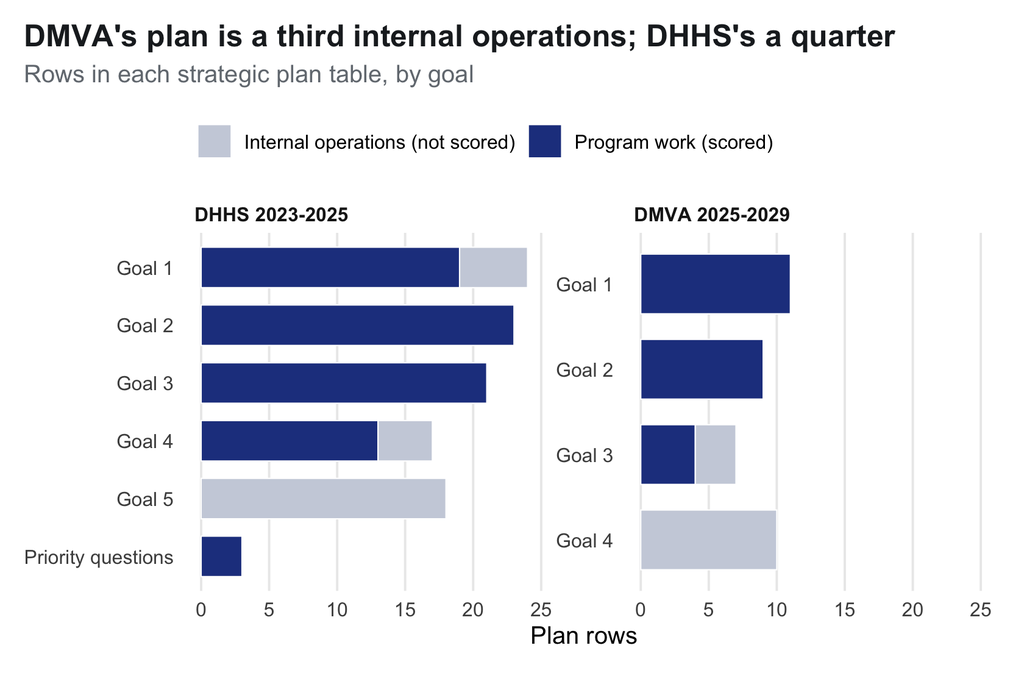

```r
load_priorities() |>
  mutate(goal = case_when(str_detect(priority_id, "^PQ") ~ "Priority questions",
                          !is.na(goal_id) ~ paste("Goal", str_remove(goal_id, "^G")),
                          TRUE ~ "Other"),
         kind = if_else(alignable, "Program work (scored)", "Internal operations (not scored)"),
         agency = paste(agency, if_else(agency == "DHHS", "2023-2025", "2025-2029"))) |>
  count(agency, goal, kind) |>
  ggplot(aes(n, fct_rev(goal), fill = kind)) +
  geom_col(width = .7, color = "white", linewidth = .3) +
  facet_wrap(~ agency, scales = "free_y") +
  scale_fill_manual(values = c("Program work (scored)" = pal$blue, "Internal operations (not scored)" = "#CBD1DD"), name = NULL) +
  labs(title = "DMVA's plan is a third internal operations; DHHS's a quarter",
       subtitle = "Rows in each strategic plan table, by goal", x = "Plan rows", y = NULL) +
  theme(legend.position = "top", legend.justification = "left", panel.grid.major.y = element_blank(),
        strip.text = element_text(face = "bold", hjust = 0))
```

Only program rows can match a federal grant. Leaving internal-operations rows in let grant boilerplate about staff and budgets look “aligned” (section 15).

The dictionary below is the team’s written one (`data/manual/data_dictionary.csv`). The “filled” and example columns are computed from the file on every render.

**Data dictionary**

```r
filled <- tibble(column = names(grants_raw),
                 filled = map_int(grants_raw, ~ sum(!is.na(.x))),
                 example = map_chr(grants_raw, ~ str_trunc(as.character(na.omit(.x)[1] %||% ""), 50)))
readr::read_csv(file.path(DIR_MANUAL, "data_dictionary.csv"), col_types = readr::cols(.default = "c")) |>
  full_join(filled, by = "column") |>
  transmute(group = coalesce(group, "(not in written dictionary)"), column, filled,
            `what it is` = what_it_is, `why it matters` = why_it_matters, example) |>
  dt(pageLength = 40, dom = "ft")
```

| group | column | filled | what it is | why it matters | example |
| --- | --- | --- | --- | --- | --- |
| Identity and status | opportunity_id | 1662 | Unique ID | Join key. No duplicates. | 3f8c97e2-901a-44c4-b9ac-b6b941c29d42 |
| Identity and status | opportunity_number | 1662 | The agency's own announcement number | The prefix tells you the type: PA/PAR/PD/RFA means an NIH-style research announcement. | O-OVW-2026-172633 |
| Identity and status | opportunity_title | 1662 | Program name | Activity codes in parentheses like (R01) or (U54) are another research signal. | OVW Fiscal Year 2026 Grants to Improve the Crim... |
| Identity and status | opportunity_status | 1662 | posted or forecasted | Duplicate of is_forecast. Ignore one. | posted |
| Identity and status | url | 1662 | Link to the opportunity page | Full coverage; all one website. | https://simpler.grants.gov/opportunity/3f8c97e2... |
| Who is issuing it | agency_code | 1662 | Org code like HHS-NIH11 | Most useful single filter in the file: the HHS-NIH prefix catches nearly all the research grants. | USDOJ-OJP-OVW |
| Who is issuing it | agency_name | 1662 | Sub-agency name | Use for routing to a division. | Office on Violence Against Women |
| Who is issuing it | top_level_agency_name | 1662 | Cabinet department | Too coarse alone. HHS contains both NIH research and CDC program money. | Department of Justice |
| Who is issuing it | agency_contact_description | 1662 | Contact info | Sometimes has a named program officer. Useful for a one-pager. | For assistance with the requirements of this NO... |
| Who is issuing it | agency_email_address | 1613 | Contact email | Same. | OVW.ICJR@usdoj.gov |

[output cut: 30 more lines]

**What is missing from the structured data.** Counting opportunities whose text (title, abstract, eligibility and description fields) mentions each requirement shows how little of a go/no-go decision the export carries:

**Requirement mentions across all opportunities**

```r
req_patterns <- c(
  "A specific match percentage"    = MATCH_PCT_PATTERN,
  "Non-federal share or match"     = "non-federal (share|match)",
  "In-kind contribution"           = "in-kind",
  "Letter of intent"               = "letters? of intent",
  "Letters of support/commitment"  = "letters? of (support|commitment)",
  "Evaluation plan"                = "evaluation plan",
  "Memorandum of understanding"    = "memorand(um|a) of understanding|\\bmou\\b",
  "Indirect cost terms"            = "indirect cost",
  "Subrecipients or subawards"     = "sub-?recipient|sub-?award")
tibble(requirement = names(req_patterns),
       opportunities = map_int(req_patterns, ~ sum(str_detect(grants$match_text, regex(.x, ignore_case = TRUE))))) |>
  dt(dom = "t")
```

| requirement | opportunities |
| --- | --- |
| A specific match percentage | 6 |
| Non-federal share or match | 3 |
| In-kind contribution | 4 |
| Letter of intent | 3 |
| Letters of support/commitment | 12 |
| Evaluation plan | 7 |
| Memorandum of understanding | 9 |
| Indirect cost terms | 16 |
| Subrecipients or subawards | 111 |

**What kinds of funding are in the file.**

**Funding instruments and categories**

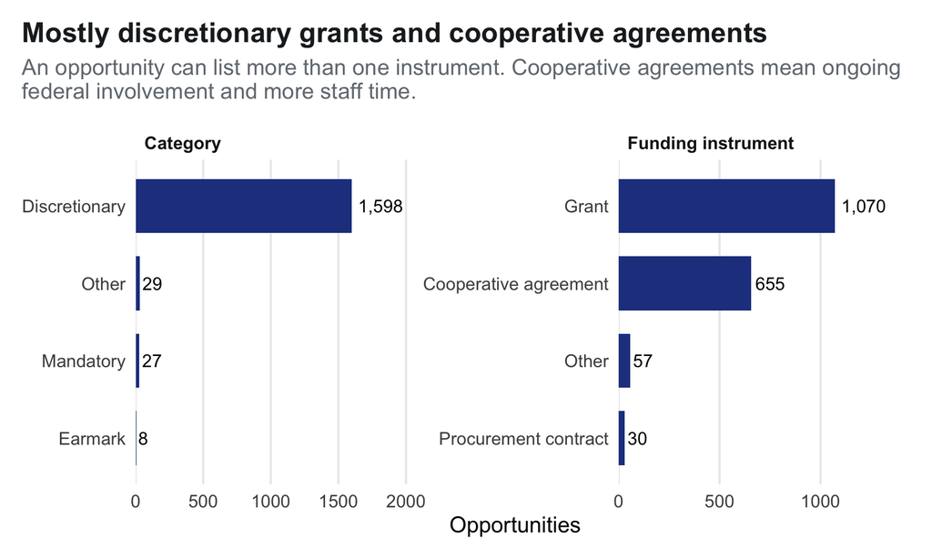

```r
bind_rows(
  tibble(value = unlist(grants$instrument_list), panel = "Funding instrument"),
  tibble(value = grants$category, panel = "Category")) |>
  mutate(value = str_replace_all(str_to_sentence(value), "_", " ")) |>
  count(panel, value) |>
  ggplot(aes(n, reorder(value, n))) +
  geom_col(fill = pal$blue, width = .7) +
  geom_text(aes(label = n_fmt(n)), hjust = -.15, size = 3.4) +
  facet_wrap(~ panel, scales = "free", ncol = 2) +
  scale_x_continuous(expand = expansion(mult = c(0, .28))) +
  labs(title = "Mostly discretionary grants and cooperative agreements",
       caption = NULL,
       subtitle = str_wrap("An opportunity can list more than one instrument. Cooperative agreements mean ongoing federal involvement and more staff time.", 85),
       x = "Opportunities", y = NULL) +
  theme(strip.text = element_text(face = "bold", hjust = 0), panel.grid.major.y = element_blank())
```

Almost everything is discretionary, which means competitive: an application costs staff weeks with no guarantee. About four in ten are cooperative agreements, where the federal agency stays involved and reporting takes more staff time.

# 5. Preprocessing

Every column is read as text and converted explicitly. Letting the reader guess types from the first 1,000 rows silently turned `forecasted_close_date_description` into a logical column and dropped 151 values. Dates outside 2000-01-01 to 2035-12-31 (including the 2099-01-01 sentinel) are kept in `*_raw` columns and removed from analysis. HTML is stripped from abstracts.

**Date outlier audit**

```r
tibble(
  check = c("Close date is the 2099-01-01 sentinel", "Posted rows with no close date",
            "Rows with any out-of-range date", "Close date before post date",
            "Closed in the 60 days before the pull date"),
  rows = c(sum(grants$close_date_raw >= as.Date("2099-01-01"), na.rm = TRUE),
           sum(grants$status_group == "Posted" & is.na(grants$close_date)),
           sum(grants$date_outlier_flag),
           sum(grants$close_date < grants$post_date, na.rm = TRUE),
           as.integer(fact_val("Rows closed in the 60 days before the pull date")))
) |> dt(dom = "t")
```

| check | rows |
| --- | --- |
| Close date is the 2099-01-01 sentinel | 11 |
| Posted rows with no close date | 123 |
| Rows with any out-of-range date | 31 |
| Close date before post date | 0 |
| Closed in the 60 days before the pull date | 0 |

**Verified facts.** Before building anything we computed 24 facts directly from the file. The pipeline must reproduce each one; the table below is recomputed on every render.

**Verified facts check**

```r
facts |> dt(dom = "t", pageLength = 30)
```

| fact | expected | computed | result |
| --- | --- | --- | --- |
| Rows / columns | 1,662 / 40 | 1,662 / 40 | PASS |
| Posted / forecasted | 1,103 / 559 | 1,103 / 559 | PASS |
| Open, state-eligible, closing on or after 2026-11-14 | 296 | 296 | PASS |
| Of those, NIH-issued | 272 | 272 | PASS |
| Of those, non-NIH | 24 | 24 | PASS |
| Rows listing state_governments as eligible | 887 | 887 | PASS |
| Of those, state-government-only | 12 | 12 | PASS |
| Of those, 3 or fewer applicant types | 36 | 36 | PASS |
| Applicant-type breadth: rows listing 1 type / 15 types | 630 / 587 | 630 / 587 | PASS |
| Application window n | 471 | 471 | PASS |

[output cut: 14 more lines]

24 of 24 rows pass. One row was corrected during the build: our original count of rows stating a match percentage was 1; the code found 6, all six were checked by hand, and the fact was changed to 6.

# 6. The haystack

**Funnel from the full file to the three piles**

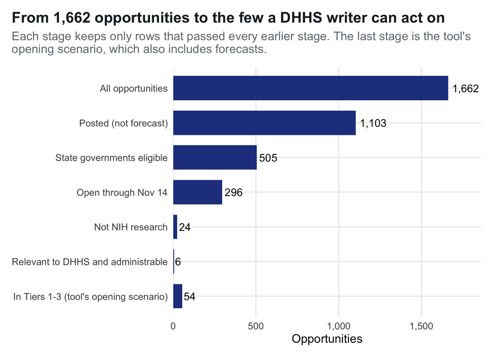

```r
dhhs_view <- keep(opps, ~ "DHHS" %in% unlist(.x$audience))
nonnih_open <- open_state |> filter(!is_nih)
relevant <- nonnih_open |> filter(opportunity_number %in% map_chr(dhhs_view, "number"),
  !map_lgl(opportunity_number, function(n) { o <- keep(opps, ~ .x$number == n)[[1]]
    s <- o$screen; isTRUE(s$is_research_mechanism) || isTRUE(s$is_restricted) || isTRUE(s$not_administrable) }))
funnel <- tibble(
  stage = c("All opportunities", "Posted (not forecast)", "State governments eligible",
            paste("Open through", format(cutoff_date, "%b %d")), "Not NIH research",
            "Relevant to DHHS and administrable", "In Tiers 1-3 (tool's opening scenario)"),
  n = c(nrow(grants), sum(grants$status_group == "Posted"),
        sum(grants$status_group == "Posted" & grants$state_eligible), nrow(open_state),
        nrow(nonnih_open), nrow(relevant), sum(opening$placement == "pile" & opening$tier <= 3))
) |> mutate(stage = factor(stage, levels = rev(stage)))
ggplot(funnel, aes(n, stage)) +
  geom_col(fill = pal$blue, width = .7) +
  geom_text(aes(label = n_fmt(n)), hjust = -.15, size = 3.8) +
  scale_x_continuous(labels = comma, expand = expansion(mult = c(0, .12))) +
  labs(title = "From 1,662 opportunities to the few a DHHS writer can act on",
       subtitle = str_wrap("Each stage keeps only rows that passed every earlier stage. The last stage is the tool's opening scenario, which also includes forecasts.", 95),
       x = "Opportunities", y = NULL)
```

The largest single drop is NIH. 92% of open, state-eligible opportunities are NIH research awards that expect a university investigator. Of the 24 that remain, most are not health and human services work at all: economic development, outdoor recreation, traffic safety, agriculture, museums. After the labeler’s review, 6 are relevant to DHHS and administrable by a state agency.

The file also ages quickly: 355 opportunities listed as posted in the August 18 export were closed or archived when we re-checked Grants.gov on 2026-09-29.

**Which federal agencies issue the opportunities**

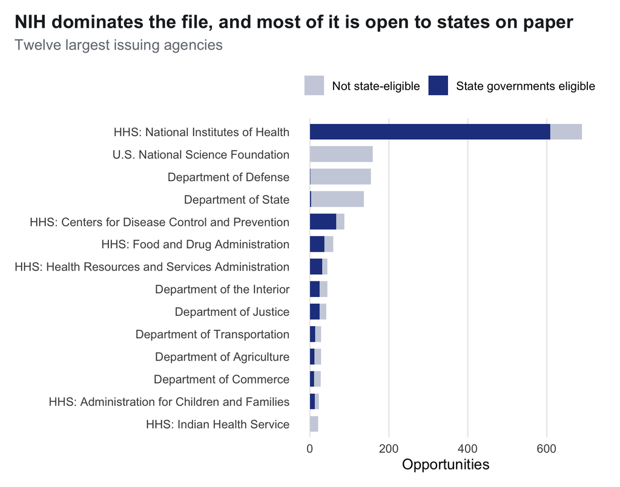

```r
grants |>
  mutate(issuer = case_when(is_nih ~ "HHS: National Institutes of Health",
                            str_detect(agency_name, "^Centers for Disease Control") ~ "HHS: Centers for Disease Control and Prevention",
                            str_detect(agency_code, "^HHS") ~ paste0("HHS: ", str_remove(agency_name, " - .*$")),
                            TRUE ~ coalesce(top_level_agency_name, agency_name)),
         issuer = str_trunc(issuer, 55)) |>
  count(issuer, state_eligible) |>
  group_by(issuer) |> mutate(total = sum(n)) |> ungroup() |>
  filter(dense_rank(desc(total)) <= 12) |>
  mutate(issuer = fct_reorder(issuer, total),
         state_eligible = if_else(state_eligible, "State governments eligible", "Not state-eligible")) |>
  ggplot(aes(n, issuer, fill = state_eligible)) +
  geom_col(width = .7) +
  scale_fill_manual(values = c("State governments eligible" = pal$blue, "Not state-eligible" = "#CBD1DD"), name = NULL) +
  labs(title = "NIH dominates the file, and most of it is open to states on paper",
       subtitle = "Twelve largest issuing agencies", x = "Opportunities", y = NULL) +
  theme(legend.position = "top", legend.justification = "left", panel.grid.major.y = element_blank())
```

NIH issues about four times as many opportunities as any other agency, and most of its awards list state governments as eligible. “State-eligible” is therefore a weak filter.

**Status of the file’s posted opportunities when re-checked on Grants.gov**

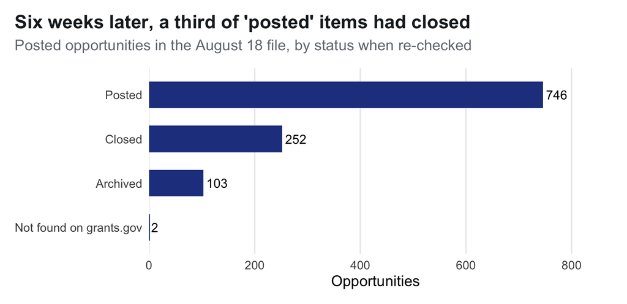

```r
enrich$status |>
  inner_join(select(grants, opportunity_number, status_group), by = "opportunity_number") |>
  filter(status_group == "Posted") |>
  mutate(status_now = str_to_sentence(coalesce(status_now, "not found on Grants.gov"))) |>
  count(status_now) |>
  ggplot(aes(n, reorder(status_now, n))) +
  geom_col(fill = pal$blue, width = .6) +
  geom_text(aes(label = n_fmt(n)), hjust = -.15, size = 3.6) +
  scale_x_continuous(expand = expansion(mult = c(0, .15))) +
  labs(title = "Six weeks later, a third of 'posted' items had closed",
       subtitle = paste0("Posted opportunities in the ", format(PULL_DATE, "%B %d"), " file, by status when re-checked"),
       x = "Opportunities", y = NULL) +
  theme(panel.grid.major.y = element_blank())
```

A snapshot goes stale within weeks. The tool shows each opportunity’s status as re-checked on Grants.gov and warns when the file and the live status disagree.

# 7. Eligibility breadth

**How many applicant types each opportunity lists**

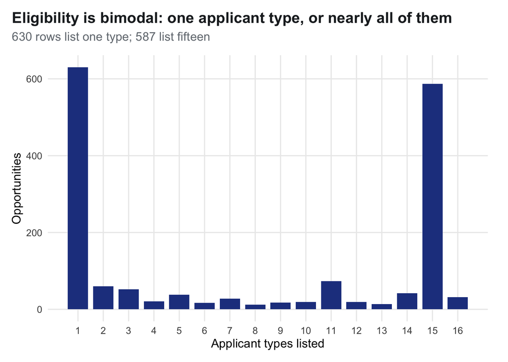

```r
ggplot(grants, aes(n_applicant_types)) +
  geom_bar(fill = pal$blue, width = .8) +
  scale_x_continuous(breaks = 1:16) +
  labs(title = "Eligibility is bimodal: one applicant type, or nearly all of them",
       subtitle = paste0(n_fmt(sum(grants$n_applicant_types == 1)), " rows list one type; ",
                         n_fmt(sum(grants$n_applicant_types == 15)), " list fifteen"),
       x = "Applicant types listed", y = "Opportunities")
```

887 rows list state governments. Only 12 are restricted to state governments alone, and 36 list three or fewer applicant types. For everything else a state agency competes with universities, hospitals, nonprofits and companies. Eligibility is a floor, not a signal of fit.

# 8. Deadline reality

**Application window distribution**

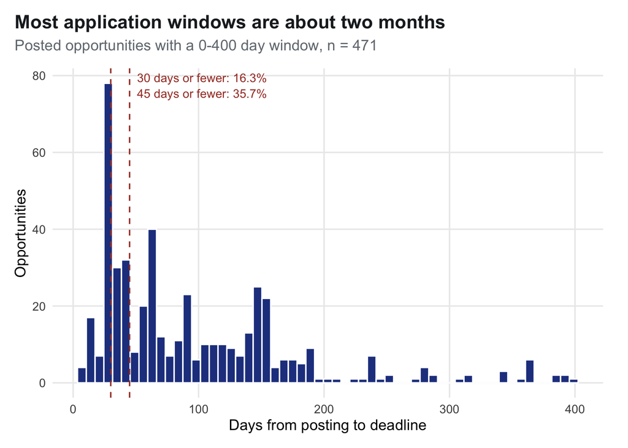

```r
ggplot(windows, aes(application_window_days)) +
  geom_histogram(binwidth = 7, fill = pal$blue, color = "white") +
  geom_vline(xintercept = WINDOW_CUTOFFS_DAYS, linetype = "dashed", color = pal$red) +
  annotate("text", x = max(WINDOW_CUTOFFS_DAYS) + 6, y = Inf, vjust = c(1.6, 3.4), hjust = 0, color = pal$red, size = 3.4,
           label = paste0(WINDOW_CUTOFFS_DAYS, " days or fewer: ",
                          pct_fmt(c(mean(windows$application_window_days <= WINDOW_CUTOFFS_DAYS[1]),
                                    mean(windows$application_window_days <= WINDOW_CUTOFFS_DAYS[2])), 1))) +
  labs(title = "Most application windows are about two months",
       subtitle = paste0("Posted opportunities with a 0-", WINDOW_MAX_DAYS, " day window, n = ", n_fmt(nrow(windows))),
       x = "Days from posting to deadline", y = "Opportunities")
```

The median window is 66 days; a quarter are 33 days or shorter and a tenth 29 or shorter. A writer who learns of a posting three weeks late has lost a third of a typical window, which is why runway is a user setting, not a fixed filter.

**When open, state-eligible opportunities close**

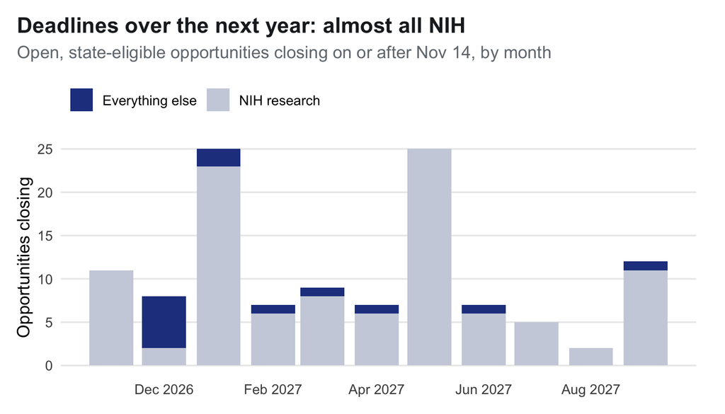

```r
open_state |>
  mutate(month = floor_date(close_date, "month"), who = if_else(is_nih, "NIH research", "Everything else")) |>
  filter(month <= REF_DATE_DEFAULT %m+% months(12)) |>
  count(month, who) |>
  ggplot(aes(month, n, fill = who)) +
  geom_col(width = 25) +
  scale_fill_manual(values = c("NIH research" = "#CBD1DD", "Everything else" = pal$blue), name = NULL) +
  scale_x_date(date_labels = "%b %Y", date_breaks = "2 months") +
  labs(title = "Deadlines over the next year: almost all NIH",
       subtitle = paste0("Open, state-eligible opportunities closing on or after ", format(cutoff_date, "%b %d"), ", by month"),
       x = NULL, y = "Opportunities closing") +
  theme(legend.position = "top", legend.justification = "left", panel.grid.major.x = element_blank())
```

**What is expected to post: state-eligible forecasts**

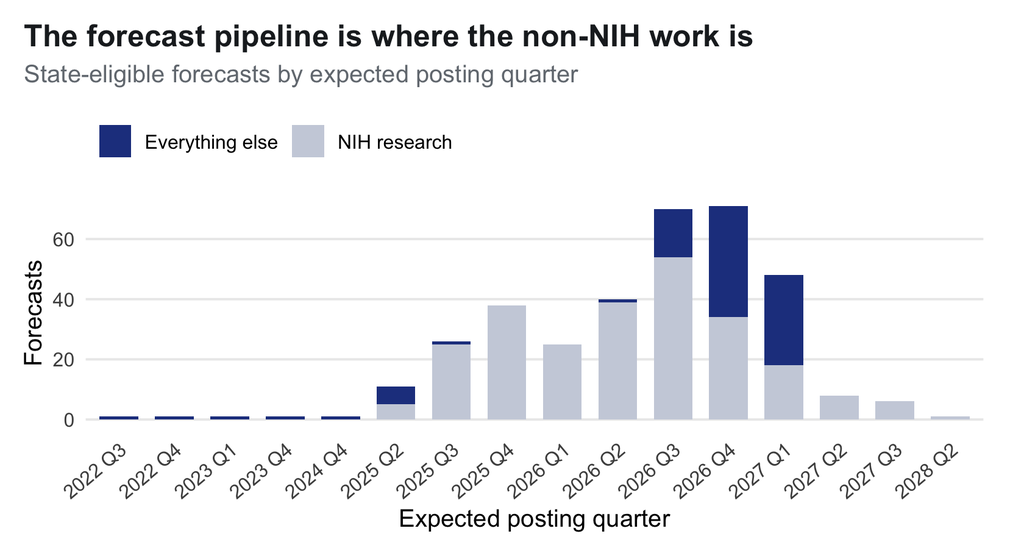

```r
grants |>
  filter(status_group == "Forecasted", state_eligible, !is.na(forecasted_post_date)) |>
  mutate(quarter = paste0(year(forecasted_post_date), " Q", quarter(forecasted_post_date)),
         who = if_else(is_nih, "NIH research", "Everything else")) |>
  count(quarter, who) |>
  ggplot(aes(quarter, n, fill = who)) +
  geom_col(width = .7) +
  scale_fill_manual(values = c("NIH research" = "#CBD1DD", "Everything else" = pal$blue), name = NULL) +
  labs(title = "The forecast pipeline is where the non-NIH work is",
       subtitle = "State-eligible forecasts by expected posting quarter",
       x = "Expected posting quarter", y = "Forecasts") +
  theme(legend.position = "top", legend.justification = "left", panel.grid.major.x = element_blank(),
        axis.text.x = element_text(angle = 40, hjust = 1))
```

Open deadlines over the next year are almost all NIH. The non-research work a DHHS writer can lead sits mostly in forecasts, which is why the tool includes forecasts by default.

# 9. What an applicant actually receives

The file’s `estimated_total_program_funding` is the national pot. Summed across open state-eligible rows it reaches $3B, a number with no meaning for one agency.

Our first version estimated what one award is worth by dividing that total by the expected number of awards. For the final version we went to the source. Every state-eligible opportunity’s current record on Grants.gov (its synopsis, or its forecast) was read, and the tool, the top results and the impact score use the **award ceiling Grants.gov states**. Only where Grants.gov states no ceiling do we fall back to an estimate: total program funding ÷ expected number of awards (Grants.gov’s figures, else the export’s). The tool marks these “est.”, and the top results say which source each award came from.

**What Grants.gov states for state-eligible opportunities**

```r
gg <- gg_awards |> inner_join(select(grants, opportunity_number, status_group, implied_award_usd, award_ceiling_clean,
                                     close_date, forecasted_close_date), by = "opportunity_number")
cat(sprintf("Grants.gov records were read for **%s** state-eligible opportunities (checked %s). **%s** state an award ceiling and **%s** an award floor; **%s** state no ceiling at all.\n",
            n_fmt(nrow(gg)), paste(unique(range(str_sub(na.omit(gg$gg_checked), 1, 10))), collapse = " to "), n_fmt(sum(!is.na(gg$gg_award_ceiling))),
            n_fmt(sum(!is.na(gg$gg_award_floor))), n_fmt(sum(is.na(gg$gg_award_ceiling)))))
```

Grants.gov records were read for **872** state-eligible opportunities (checked 2026-09-29 to 2026-09-30). **351** state an award ceiling and **162** an award floor; **521** state no ceiling at all.

**Where each award figure comes from**

```r
src_n <- table(map_chr(keep(opps, ~ isTRUE(.x$state_eligible)), ~ .x$award_basis %||% "none"))
lab <- c(grantsgov_ceiling = "Grants.gov award ceiling", total_over_awards = "estimate (total ÷ expected awards)",
         ceiling = "award ceiling in the export", none = "no figure at all")
cat("Across state-eligible opportunities, the award figure comes from: ",
    paste0(map_chr(names(src_n), ~ paste0("**", lab[[.x]], "** ", n_fmt(src_n[[.x]]))), collapse = "; "), ".\n", sep = "")
```

Across state-eligible opportunities, the award figure comes from: **award ceiling in the export** 2; **Grants.gov award ceiling** 351; **no figure at all** 392; **estimate (total ÷ expected awards)** 142.

**Grants.gov award ceiling vs the old divided estimate**

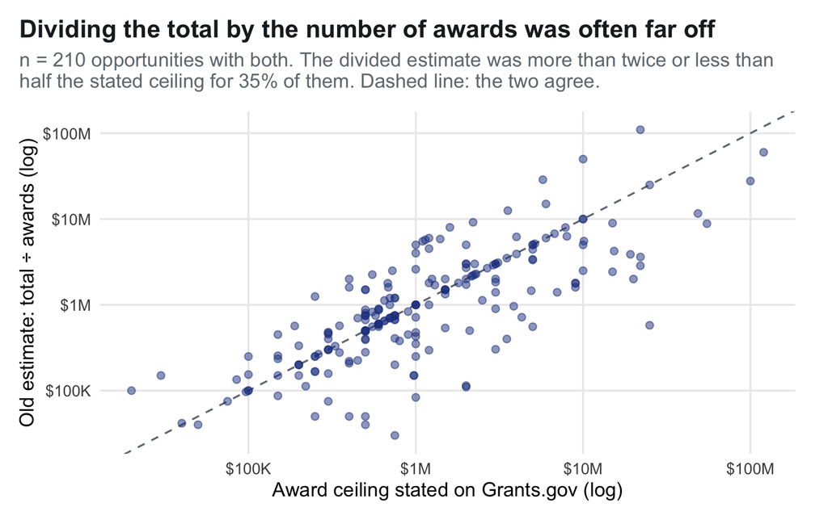

```r
cmp <- gg |> filter(!is.na(gg_award_ceiling), !is.na(implied_award_usd))
ratio <- cmp$implied_award_usd / cmp$gg_award_ceiling
ggplot(cmp, aes(gg_award_ceiling, implied_award_usd)) +
  geom_abline(slope = 1, intercept = 0, color = pal$gray, linetype = "dashed") +
  geom_point(alpha = .5, color = pal$blue, size = 1.8) +
  scale_x_log10(labels = usd_fmt, expand = expansion(mult = .05)) +
  scale_y_log10(labels = usd_fmt, expand = expansion(mult = .06)) +
  labs(title = "Dividing the total by the number of awards was often far off",
       subtitle = str_wrap(paste0("n = ", n_fmt(nrow(cmp)), " opportunities with both. The divided estimate was more than twice or less than half the stated ceiling for ",
                                  pct_fmt(mean(ratio > 2 | ratio < .5)), " of them. Dashed line: the two agree."), 90),
       x = "Award ceiling stated on Grants.gov (log)", y = "Old estimate: total ÷ awards (log)")
```

**Distribution of Grants.gov award ceilings**

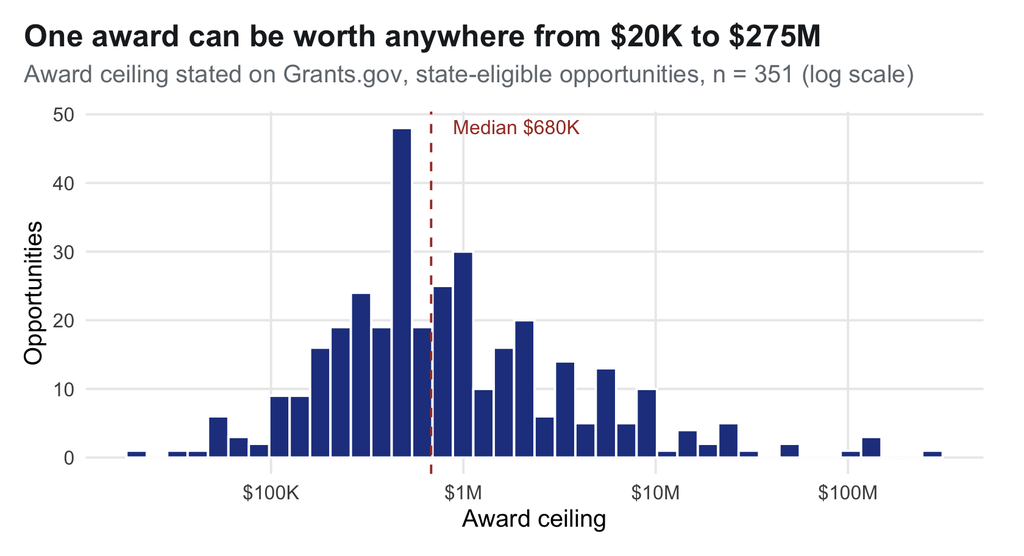

```r
ceil <- gg |> filter(!is.na(gg_award_ceiling))
ggplot(ceil, aes(gg_award_ceiling)) +
  geom_histogram(bins = 40, fill = pal$blue, color = "white") +
  geom_vline(xintercept = median(ceil$gg_award_ceiling), linetype = "dashed", color = pal$red) +
  annotate("text", x = median(ceil$gg_award_ceiling) * 1.3, y = Inf, vjust = 1.6, hjust = 0, color = pal$red, size = 3.4,
           label = paste("Median", usd_fmt(median(ceil$gg_award_ceiling)))) +
  scale_x_log10(labels = usd_fmt) +
  labs(title = "One award can be worth anywhere from $20K to $275M",
       subtitle = paste0("Award ceiling stated on Grants.gov, state-eligible opportunities, n = ", n_fmt(nrow(ceil)), " (log scale)"),
       x = "Award ceiling", y = "Opportunities")
```

**Deadlines were checked the same way.** The tool uses each opportunity’s current Grants.gov deadline (Grants.gov’s estimate, for forecasts) instead of the date in the August export:

**Grants.gov deadline vs the export’s date**

```r
gg |> mutate(export_date = if_else(status_group == "Forecasted", forecasted_close_date, close_date),
             change = case_when(is.na(gg_deadline) ~ "Grants.gov states no date",
                                is.na(export_date) ~ "Date only on Grants.gov",
                                gg_deadline == export_date ~ "Same date",
                                gg_deadline > export_date ~ "Grants.gov date is later",
                                TRUE ~ "Grants.gov date is earlier")) |>
  count(`Deadline compared with the export` = change, name = "Opportunities") |>
  arrange(desc(Opportunities)) |> dt(dom = "t")
```

| Deadline compared with the export | Opportunities |
| --- | --- |
| Same date | 807 |
| Grants.gov states no date | 39 |
| Grants.gov date is later | 22 |
| Grants.gov date is earlier | 4 |

# 10. The capability model

Each agency has a hand-authored capability profile: fourteen capabilities, each with a control level and a source. `direct` means the agency runs it; `contracted` means through a contract it controls; `partner` means another entity controls it and an agreement is needed; `none` means no route.

**Sourced capability profiles**

```r
load_capabilities() |>
  mutate(source = sprintf('<a href="%s" target="_blank">source</a>', source_url)) |>
  select(agency, capability = capability_label, control = control_level, basis = notes,
         `what resolving a gap takes` = to_resolve, source) |>
  DT::datatable(rownames = FALSE, escape = FALSE, filter = "top", class = "cell-border stripe hover",
                options = list(pageLength = 14, scrollX = TRUE))
```

| agency | capability | control | basis | what resolving a gap takes | source |
| --- | --- | --- | --- | --- | --- |
| DHHS | Clinical service delivery | contracted | Medical care is delivered through NC Medicaid Managed Care health plans and providers, not by DHHS staff | Amend or add a managed-care or provider contract (division-level decision) | source |
| DHHS | Behavioral health service delivery | contracted | LME/MCOs manage mental health, I/DD and substance use services under DHHS contracts; DHHS also runs state psychiatric hospitals directly | Route through LME/MCO contract amendment | source |
| DHHS | Long-term care facility operation | direct | Division of State Operated Healthcare Facilities runs developmental centers and Neuro-Medical Treatment Centers (CMS-certified skilled nursing) |  | source |
| DHHS | Public health surveillance | direct | Division of Public Health runs statewide surveillance, including NC DETECT behavioral health syndromic surveillance (DHHS Strategic Plan 2023-25, strategy G3.5.2, PDF p.15) |  | source |
| DHHS | Data systems and interoperability | direct | DHHS invests in enterprise data collection, integration and storage for staff and partners (DHHS Strategic Plan 2023-25, strategy G5.1.3, PDF p.19) |  | source |
| DHHS | Research and rigorous evaluation | partner | Independent evaluation is contracted to university partners, e.g. UNC Sheps Center evaluates the Medicaid 1115 waiver and Healthy Opportunities Pilots | Letter of commitment or subcontract with a university evaluator | source |
| DHHS | Housing stock or assistance | partner | DHHS does not control housing stock; affordable units are reached through the NC Housing Finance Agency Targeting Program partnership | MOU or letter of support from NC Housing Finance Agency or a housing authority | source |
| DHHS | Transportation services | contracted | Non-emergency medical transportation is provided by Medicaid health plans through transportation brokers, and by county DSS for Medicaid Direct | Add scope to health-plan or broker contract | source |
| DHHS | Workforce training and credentialing | partner | Caregiving and early childhood workforce pipelines are built 'in collaboration with partners' (DHHS Strategic Plan 2023-25, Goal 4, PDF p.17); training delivery sits with community colleges and AHEC | Partnership agreement with community colleges or AHEC | source |
| DHHS | Emergency management | partner | NC Emergency Management is a division of the Department of Public Safety and coordinates all state agencies in emergencies | Coordination agreement with NC Emergency Management (DPS) | source |

[output cut: 18 more lines]

**Capability profiles as a heatmap**

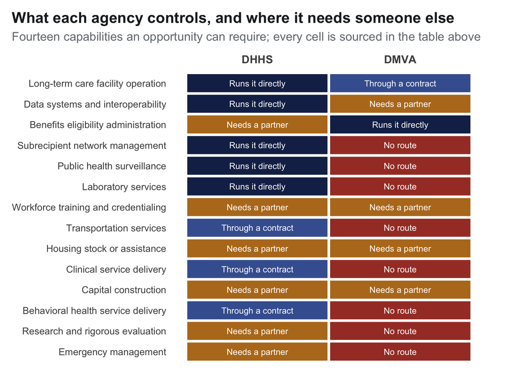

```r
lvl <- c(direct = "Runs it directly", contracted = "Through a contract", partner = "Needs a partner", none = "No route")
load_capabilities() |>
  mutate(control = factor(lvl[control_level], levels = lvl),
         capability = fct_reorder(str_wrap(capability_label, 38), as.integer(factor(control_level, levels = names(lvl))), .fun = mean, .desc = TRUE)) |>
  ggplot(aes(agency, capability, fill = control)) +
  geom_tile(color = "white", linewidth = 1.2) +
  geom_text(aes(label = control), size = 3, color = "white") +
  scale_fill_manual(values = c("Runs it directly" = "#172a55", "Through a contract" = "#43609f",
                               "Needs a partner" = "#B7791F", "No route" = "#A63D2F"), name = NULL, drop = FALSE) +
  scale_x_discrete(position = "top") +
  labs(title = "What each agency controls, and where it needs someone else",
       subtitle = "Fourteen capabilities an opportunity can require; every cell is sourced in the table above",
       x = NULL, y = NULL) +
  theme(panel.grid = element_blank(), legend.position = "none", axis.text.x = element_text(face = "bold", size = 11))
```

DHHS runs surveillance, labs, data systems and long-term care, and contracts clinical and behavioral health services, but needs partners for housing, research, workforce training, construction and emergency management. DMVA runs benefits eligibility and contracts its veterans homes; almost everything else needs a partner or has no route. Every orange or red cell is a gap that moves an opportunity to Tier 2 or Tier 3.

Housing is the demonstration case. DHHS works on housing instability but does not control housing stock; it reaches affordable units through the NC Housing Finance Agency’s Targeting Program. So housing is `partner`, and any opportunity that requires housing is at least Tier 2.

Each opportunity gets a requirement profile. For the 210 candidates it comes from the local labeler (section 12), which reads the abstract and, for 116 of them, the full announcement. For everything else it comes from deterministic rules: the structured cost-share flag, the funding instrument, and sentence-level patterns that ignore negated sentences (“funds may not be used for construction”).

# 11. Authority tiering

The rules live in one file, `src/tool/tiering.js`. The notebook does not re-implement them: the tables below come from running that file through V8.

- **Tier 3** if any of: cost share on an award at or above $1M (a stated assumption, adjustable in the tool); cost share when the writer has no match authority; a capital construction project; a formal state designation; a required capability the agency has no route to.
- **Tier 2** if not Tier 3 and any of: a required capability reached only through a partner; cost share that needs supervisor approval; funding and monitoring subrecipients; a cooperative agreement with a required evaluation; more staff time than the writer has.
- **Tier 4, partner-led research**: research awards (and programs a state agency is unlikely to lead) get their own pile below the three authority tiers. A university, research institution or other partner would be the applicant; the agency’s role is partner. Any other rules that fire are still listed on the card. The user can hide this pile.
- **Tier 1** otherwise.

Before tiering, an opportunity is set aside, visibly, if it is not relevant to the agency, is a forecast, has closed, is NIH or a research mechanism, is judged not administrable by a state agency, is restricted to named applicants, has less runway than the user needs, or is below the minimum award.

**Ranking within a pile.** The piles answer *whose signature is needed*; they are never blended with anything else. Within each pile the tool orders opportunities by an impact score whose weights the user sets: fit with the strategic plan (the labeler’s strong / partial / none), people reached, help per person, award size, and the user’s program priorities. The user can pick the one that matters most or set each weight directly, and each card shows which parts led its score. Keeping the score *inside* the piles is deliberate: a large award the agency cannot staff should not outrank a small one it can run tomorrow, so authority is decided first and impact only orders what remains.

**Tiers in the tool’s opening scenario (computed by tiering.js)**

```r
opening |> filter(placement == "pile", tier <= 3) |> arrange(tier) |>
  transmute(tier, opportunity = opportunity_title, agency = agency_code, reason = tier_reason) |>
  dt(pageLength = 15)
```

| tier | opportunity | agency | reason |
| --- | --- | --- | --- |
| 1 | Fiscal Year (FY) 2027 Service Area Competition (SAC) | HHS-HRSA | No escalation: required capabilities are in-house or contracted, no cost share, about 0.25 FTE fits your staff |
| 1 | Strengthening Services to Prevent the Infectious Disease Consequences of Drug Use | HHS-CDC-NCHHSTP | No escalation: required capabilities are in-house or contracted, no cost share, about 0.5 FTE fits your staff |
| 1 | Centers of Excellence in Healthcare Quality and Safety | HHS-CDC-NCEZID | No escalation: required capabilities are in-house or contracted, no cost share, about 0.5 FTE fits your staff |
| 1 | HIV Care Grant Program - Part B States/Territories Formula and AIDS Drug Assistance Program Formula and AIDS Drug Assistance Program Supplemental Awards | HHS-HRSA | No escalation: required capabilities are in-house or contracted, no cost share, about 0.25 FTE fits your staff |
| 1 | State Occupational Safety and Health Surveillance Program (U60) | HHS-CDC-HHSCDCERA | No escalation: required capabilities are in-house or contracted, no cost share, about 0.5 FTE fits your staff |
| 1 | Rural Health Network Development Program | HHS-HRSA | No escalation: required capabilities are in-house or contracted, no cost share, about 0.25 FTE fits your staff |
| 1 | Fiscal Year (FY) Service Area Competition (SAC) | HHS-HRSA | No escalation: required capabilities are in-house or contracted, no cost share, about 0.25 FTE fits your staff |
| 1 | Manufactured Foods Flexible Funding Model (MF-FFM) | HHS-FDA | No escalation: required capabilities are in-house or contracted, no cost share, about 0.5 FTE fits your staff |
| 1 | Expanded Surveillance for Pediatric Infectious Diseases | HHS-CDC-HHSCDCERA | No escalation: required capabilities are in-house or contracted, no cost share, about 0.5 FTE fits your staff |
| 1 | Fetal, Infant, and Child Death Review Program | HHS-HRSA | No escalation: required capabilities are in-house or contracted, no cost share, about 0.5 FTE fits your staff |

[output cut: 44 more lines]

**How the piles change with the writer’s situation (tiering.js at each preset)**

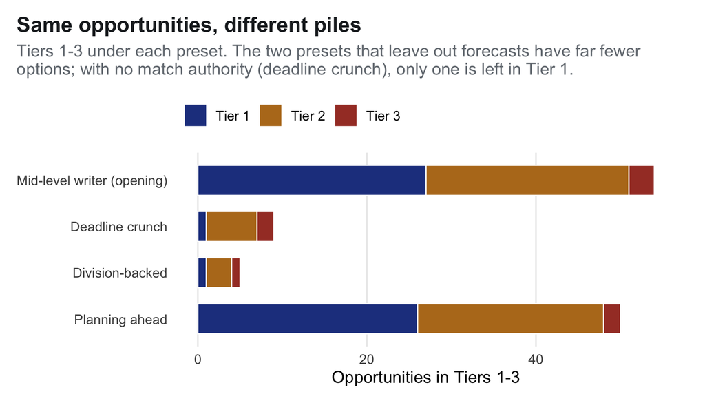

```r
scen <- map(payload$config$presets, ~ list(label = paste0(.x$label, if (.x$id == payload$config$opening_preset) " (opening)" else ""),
                                             settings = modifyList(payload$config$opening, .x$settings)))
map_dfr(scen, function(sc) {
  run_tiering_js(opps, payload$capabilities$profiles, sc$settings) |>
    filter(placement == "pile", tier <= 3) |> count(tier) |> mutate(scenario = sc$label)
}) |>
  mutate(tier = factor(paste("Tier", tier), levels = paste("Tier", 3:1)),
         scenario = factor(scenario, levels = rev(map_chr(scen, "label")))) |>
  ggplot(aes(n, scenario, fill = tier)) +
  geom_col(width = .65, color = "white", linewidth = .4) +
  scale_fill_manual(values = c("Tier 1" = pal$tier1, "Tier 2" = pal$tier2, "Tier 3" = pal$tier3), name = NULL,
                    breaks = paste("Tier", 1:3)) +
  labs(title = "Same opportunities, different piles",
       subtitle = str_wrap("Tiers 1-3 under each preset. The two presets that leave out forecasts have far fewer options; with no match authority (deadline crunch), only one is left in Tier 1.", 90),
       x = "Opportunities in Tiers 1-3", y = NULL) +
  theme(legend.position = "top", legend.justification = "left", panel.grid.major.y = element_blank())
```

**Program areas in the opening scenario’s piles**

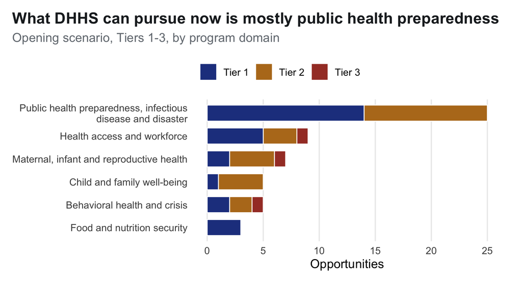

```r
dom_of <- setNames(map_chr(opps, ~ .x$domain %||% NA_character_), map_chr(opps, "number"))
opening |> filter(placement == "pile", tier <= 3) |>
  mutate(domain = coalesce(unname(DOMAINS[dom_of[opportunity_number]]), "No domain assigned"),
         tier = factor(paste("Tier", tier), levels = paste("Tier", 3:1))) |>
  count(domain, tier) |>
  ggplot(aes(n, fct_reorder(str_wrap(domain, 40), n, sum), fill = tier)) +
  geom_col(width = .7, color = "white", linewidth = .4) +
  scale_fill_manual(values = c("Tier 1" = pal$tier1, "Tier 2" = pal$tier2, "Tier 3" = pal$tier3), name = NULL,
                    breaks = paste("Tier", 1:3)) +
  labs(title = "What DHHS can pursue now is mostly public health preparedness",
       subtitle = "Opening scenario, Tiers 1-3, by program domain", x = "Opportunities", y = NULL) +
  theme(legend.position = "top", legend.justification = "left", panel.grid.major.y = element_blank())
```

Preparedness and infectious disease dominate what DHHS can pursue now, mostly through CDC cooperative agreements with health departments. Other program areas depend on forecasts posting.

**The impact score, part by part.** Inside each pile the tool orders opportunities by an impact score from 0 to 100, built from five actual numbers. Each number earns points, and the points add up to the score. With the default equal weights each part can add at most 20 points:

| Part | The actual number | How it earns points |
| --- | --- | --- |
| Plan fit | The labeler’s rating of fit with the agency’s strategic plan | Strong earns all 20, partial 10, none 0 |
| People reached | North Carolinians in the population the opportunity serves | By its rank among the opportunities in view: the largest earns 20, the median about 10 |
| Help per person | Award ceiling divided by that population | By its rank, the same way |
| Award size | The award ceiling stated on Grants.gov | By its rank, the same way |
| Program priorities | The writer’s weight for the opportunity’s program area (default 1 of 3) | Weight ÷ 3 × 20: 6.7 points at the default |

**Impact score broken into its five parts (opening scenario, DHHS)**

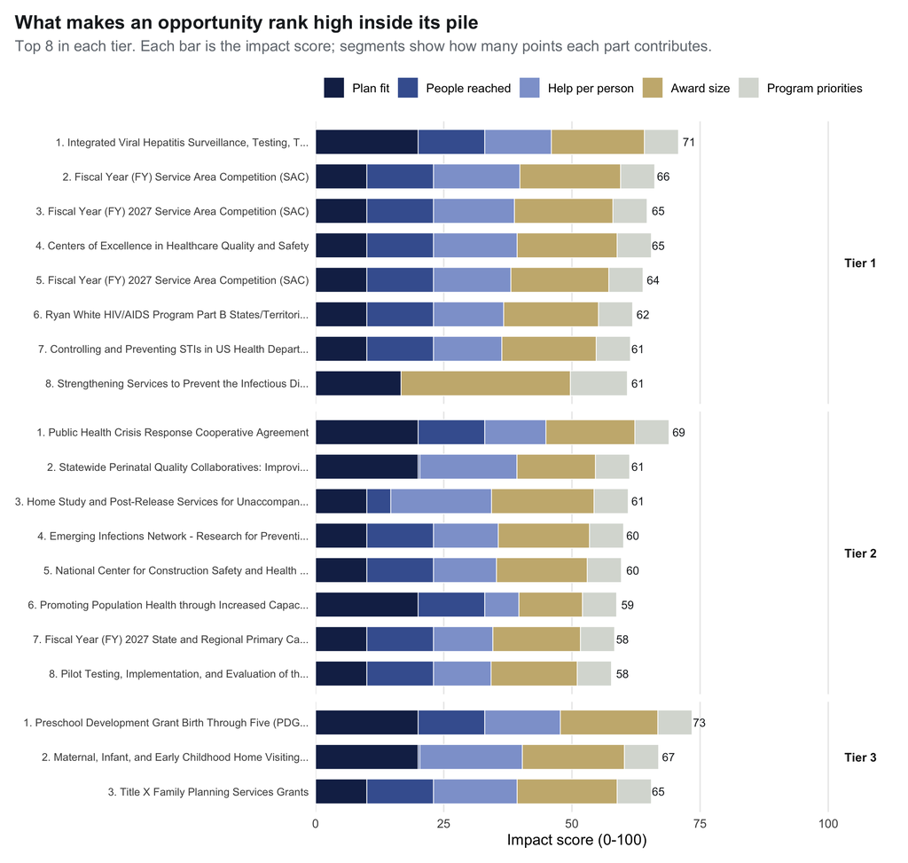

```r
part_lab <- c(alignment = "Plan fit", reach = "People reached", depth = "Help per person",
              award = "Award size", priority = "Program priorities")
imp <- keep(run_tiering_piles_js(payload, payload$config$opening), ~ .x$tier <= 3) |>
  map_dfr(function(r) {
    p <- r$parts
    tibble(opportunity_number = r$number, tier = r$tier, rank = r$rank_in_tier, score = r$impact %||% NA_real_,
           !!!setNames(map(names(part_lab), ~ p[[.x]] %||% NA_real_), names(part_lab)))
  }) |> left_join(titles, by = "opportunity_number")
contrib <- imp |> filter(rank <= 8) |>
  pivot_longer(all_of(names(part_lab)), names_to = "part", values_to = "value") |>
  group_by(opportunity_number) |> mutate(n_known = sum(!is.na(value))) |> ungroup() |>
  mutate(points = 100 * value / n_known, part = factor(part_lab[part], levels = rev(part_lab)),
         tier = paste("Tier", tier),
         label = fct_reorder(paste0(rank, ". ", str_trunc(opportunity_title, 54)), -rank)) |>
  filter(!is.na(value))
ggplot(contrib, aes(points, label, fill = part)) +
  geom_col(width = .72, color = "white", linewidth = .3) +
  geom_text(data = distinct(contrib, tier, label, score), aes(score, label, label = score), inherit.aes = FALSE,
            hjust = -.25, size = 3.2, color = pal$dark) +
  facet_grid(tier ~ ., scales = "free_y", space = "free_y") +
  scale_fill_manual(values = c("Plan fit" = "#172a55", "People reached" = "#43609f", "Help per person" = "#8ea2d2",
                               "Award size" = "#C9B57E", "Program priorities" = "#D9DCD6"),
                    breaks = unname(part_lab), name = NULL) +
  scale_x_continuous(limits = c(0, 100), expand = expansion(mult = c(0, .02))) +
  labs(title = "What makes an opportunity rank high inside its pile",
       subtitle = "Top 8 in each tier. Each bar is the impact score; segments show how many points each part contributes.",
       x = "Impact score (0-100)", y = NULL) +
  theme(legend.position = "top", legend.justification = "left", panel.grid.major.y = element_blank(),
        strip.text.y = element_text(angle = 0, face = "bold"), axis.text.y = element_text(size = 8.5))
```

**Every Tier 1-3 opportunity: the actual numbers behind its impact score**

```r
build_top_results(payload, "DHHS") |>
  transmute(tier, rank = rank_in_tier, opportunity = title, `impact score` = impact_score,
            `plan fit` = paste0(plan_fit_rating, " → ", plan_fit_points),
            `people reached` = if_else(is.na(people_reached), "no estimate",
                                       paste0(n_fmt(round(people_reached)), " → ", people_reached_points)),
            `help per person` = if_else(is.na(help_per_person_usd), "n/a",
                                        paste0(dollar(help_per_person_usd, accuracy = .01), " → ", help_per_person_points)),
            `award` = if_else(is.na(estimated_award), "no figure",
                              paste0(usd_fmt(estimated_award), if_else(award_source == "Estimate: total funding / expected awards", " (est.)", ""),
                                     " → ", award_size_points)),
            `program priority` = paste0(coalesce(program_area, "none"), " (weight ", priority_weight, ") → ", program_priorities_points)) |>
  dt(pageLength = 10)
```

| tier | rank | opportunity | impact score | plan fit | people reached | help per person | award | program priority |
| --- | --- | --- | --- | --- | --- | --- | --- | --- |
| 1 | 1 | Integrated Viral Hepatitis Surveillance, Testing, Treatment, and Prevention Programs for Health Departments (IVH-STTP) | 71 | strong → 20 | 10,584,340 → 13 | $0.71 → 13 | $7.5000M (est.) → 18.1 | Public health preparedness, infectious disease and disaster (weight 1) → 6.7 |
| 1 | 2 | Fiscal Year (FY) Service Area Competition (SAC) | 66 | partial → 10 | 10,584,340 → 13 | $2.08 → 16.8 | $22.0249M → 19.6 | Health access and workforce (weight 1) → 6.7 |
| 1 | 3 | Fiscal Year (FY) 2027 Service Area Competition (SAC) | 65 | partial → 10 | 10,584,340 → 13 | $1.81 → 15.8 | $19.1820M → 19.2 | Health access and workforce (weight 1) → 6.7 |
| 1 | 4 | Centers of Excellence in Healthcare Quality and Safety | 65 | partial → 10 | 10,584,340 → 13 | $2.08 → 16.3 | $22.0000M → 19.5 | Public health preparedness, infectious disease and disaster (weight 1) → 6.7 |
| 1 | 5 | Fiscal Year (FY) 2027 Service Area Competition (SAC) | 64 | partial → 10 | 10,584,340 → 13 | $1.45 → 15.1 | $15.3355M → 19.1 | Health access and workforce (weight 1) → 6.7 |
| 1 | 6 | Ryan White HIV/AIDS Program Part B States/Territories Supplemental Grant Program | 62 | partial → 10 | 10,584,340 → 13 | $0.85 → 13.7 | $9.0000M → 18.5 | Behavioral health and crisis (weight 1) → 6.7 |
| 1 | 7 | Controlling and Preventing STIs in US Health Departments (CAP-STIs) | 61 | partial → 10 | 10,584,340 → 13 | $0.80 → 13.3 | $8.4746M (est.) → 18.4 | Public health preparedness, infectious disease and disaster (weight 1) → 6.7 |
| 1 | 8 | Strengthening Services to Prevent the Infectious Disease Consequences of Drug Use | 61 | partial → 16.7 | no estimate | n/a | $41.2500M (est.) → 33 | Public health preparedness, infectious disease and disaster (weight 1) → 11.1 |
| 1 | 9 | HIV Care Grant Program - Part B States/Territories Formula and AIDS Drug Assistance Program Formula and AIDS Drug Assistance Program Supplemental Awards | 57 | partial → 10 | 1,073,923 → 1.3 | $20.22 → 19.3 | $21.7167M (est.) → 19.3 | Public health preparedness, infectious disease and disaster (weight 1) → 6.7 |
| 1 | 10 | AIDS Drug Assistance Program (ADAP) Emergency Relief Funds (ERF) | 56 | partial → 10 | 1,402,172 → 2.7 | $7.13 → 18.2 | $10.0000M → 18.7 | Behavioral health and crisis (weight 1) → 6.7 |

[output cut: 44 more lines]

Each cell reads “actual number → points”. The points in a row add up to the impact score (small differences are rounding).

The score is transparent by design. A writer can see that an opportunity ranks high because of its reach or its award, not a black-box number, and can change the weights in the tool.

**The rule tests the build must pass**

```r
cases <- jsonlite::fromJSON(here::here("src", "tool", "tiering_cases.json"))
tibble(test = cases$cases$name) |> dt(dom = "t", pageLength = 30)
```

| test |
| --- |
| clean grant is Tier 1 |
| contracted capability stays Tier 1 |
| partner capability is Tier 2 |
| no-route capability is Tier 3 |
| small cost share with approval is Tier 2 |
| small cost share with authority is Tier 1 |
| cost share without authority is Tier 3 |
| large cost share needs appropriation |
| capital project is Tier 3 |
| designation is Tier 3 |

[output cut: 19 more lines]

# 12. LLM labeling

**Method.** A local model (qwen2.5:14b, run through Ollama; prompt v3.1) labels each candidate from its abstract plus a fixed excerpt of its full announcement: the first 2,500 characters, then sentences that mention match, subawards, evaluation, construction, designation or renewal. Output must match a JSON schema with closed vocabularies, at temperature 0 and a fixed seed, and evidence fields must quote the text.

**Caching.** Each response is stored under a SHA-256 hash of the model digest, prompt version, and exact prompt. Rendering this notebook never calls the model; the labels below are read from that cache.

**Labeling coverage**

```r
if (labels_ok) {
  cat(sprintf("Labeled: **%s of %s** candidates; **%s** had a full announcement. Median model time per opportunity: %s seconds.\n",
              n_fmt(sum(labels$labeled)), n_fmt(nrow(labels)), n_fmt(sum(labels$labeled & labels$has_nofo)),
              round(median(labels$llm_seconds, na.rm = TRUE))))
} else {
  cat('<div class="pending">Labeling has not finished; this section fills in when <code>data/processed/llm_labels.rds</code> exists.</div>')
}
```

**What the labeler could read.** A full announcement usually exists only once an opportunity posts, so the model reads forecasts from their short abstracts alone.

**Full-announcement coverage among candidates**

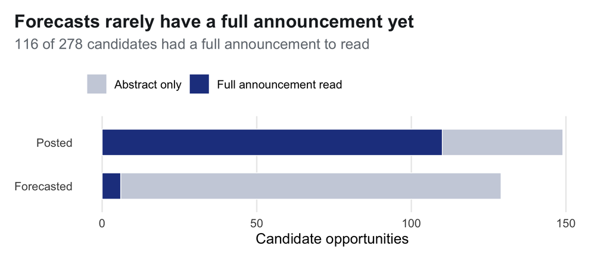

```r
enrich$nofo |>
  left_join(select(grants, opportunity_number, status_group), by = "opportunity_number") |>
  mutate(read = if_else(!is.na(nofo_text), "Full announcement read", "Abstract only"),
         status_group = coalesce(status_group, "Other")) |>
  count(status_group, read) |>
  ggplot(aes(n, status_group, fill = read)) +
  geom_col(width = .6, color = "white", linewidth = .3) +
  scale_fill_manual(values = c("Full announcement read" = pal$blue, "Abstract only" = "#CBD1DD"), name = NULL) +
  labs(title = "Forecasts rarely have a full announcement yet",
       subtitle = paste0(n_fmt(nofo_n), " of ", n_fmt(cand_n), " candidates had a full announcement to read"),
       x = "Candidate opportunities", y = NULL) +
  theme(legend.position = "top", legend.justification = "left", panel.grid.major.y = element_blank())
```

**Prompt v2 vs v3 on the same opportunities**

```r
v2_path <- file.path(DIR_PROCESSED, "llm_labels_v2_partial.rds")
if (labels_ok && file.exists(v2_path)) {
  v2 <- readRDS(v2_path) |> filter(labeled)
  both <- inner_join(v2, filter(labels, labeled), by = "opportunity_number", suffix = c("_v2", "_v3"))
  rate <- function(x) pct_fmt(mean(x, na.rm = TRUE))
  tibble(
    measure = c("Rated at least partially aligned with DHHS", "Judged administrable by a state agency",
                "Placed in the preparedness / disaster domain (D08)", "Placed in no domain",
                "Formal evaluation required", "Match required (with a quoted source)"),
    `prompt v2` = c(rate(both$llm_align_dhhs_v2 %in% c("strong", "partial")), rate(both$llm_administrable_v2),
                    rate(both$llm_domain_v2 == "D08"), rate(both$llm_domain_v2 == "none"),
                    rate(both$llm_evaluation_v2), rate(both$llm_match_required_v2 %in% TRUE)),
    `prompt v3` = c(rate(both$llm_align_dhhs_v3 %in% c("strong", "partial")), rate(both$llm_administrable_v3),
                    rate(both$llm_domain_v3 == "D08"), rate(both$llm_domain_v3 == "none"),
                    rate(both$llm_evaluation_v3), rate(both$llm_match_required_v3))
  ) |> dt(dom = "t")
} else HTML('<div class="pending">Fills in when the v3 labels exist.</div>')
```

| measure | prompt v2 | prompt v3 |
| --- | --- | --- |
| Rated at least partially aligned with DHHS | 68% | 22% |
| Judged administrable by a state agency | 94% | 34% |
| Placed in the preparedness / disaster domain (D08) | 48% | 8% |
| Placed in no domain | 32% | 78% |
| Formal evaluation required | 58% | 36% |
| Match required (with a quoted source) | 24% | 24% |

**Examples where v3 withdrew DHHS alignment**

```r
if (labels_ok && file.exists(v2_path)) {
  both |> filter(llm_align_dhhs_v2 %in% c("strong", "partial"), llm_align_dhhs_v3 == "none") |>
    left_join(titles, by = "opportunity_number") |>
    transmute(opportunity = opportunity_title, agency = agency_code,
              `v2 alignment` = llm_align_dhhs_v2, `v2 reason` = llm_align_dhhs_why_v2,
              `v3 administrable` = llm_administrable_v3, `v3 domain` = llm_domain_v3) |>
    dt(pageLength = 8)
}
```

| opportunity | agency | v2 alignment | v2 reason | v3 administrable | v3 domain |
| --- | --- | --- | --- | --- | --- |
| Use of Digital Health Technologies in Clinical Investigations to Support Drug and Biological Product Development (U01) Clinical Trials Optional | HHS-FDA | partial | The opportunity emphasizes the use of digital health technologies for remote data acquisition, which aligns with the goal of using data to hold partners accountable. | False | none |
| Fiscal Year 2026 National Incident Management System (NIMS) | DHS-DHS | partial | The opportunity aims to strengthen interconnectivity and collaboration between federal agencies and non-federal partners, which aligns with the objective of investing in the capacity of partners to ov… | True | none |
| FY26 Community Policing Development (CPD) Accreditation Program | USDOJ-OJP-COPS | partial | The opportunity aims to support local capacity to overcome persistent health inequities by expanding law enforcement accreditation, which can indirectly improve community health and safety. | False | none |
| FY26 Safer Outcomes Program | USDOJ-OJP-COPS | strong | The opportunity supports expanding access to behavioral health supports for people involved in the justice system, which aligns with the strategic plan objective. | False | none |
| FY26 Bureau of Land Management Fuels Management and Community Fire Assistance - Bureau wide | DOI-BLM | partial | The program supports local capacity to overcome persistent health inequities by providing training and assistance to communities to become fire adapted and reduce wildfire risks. | False | none |
| FY26 National Dam Safety Program State Assistance Program | DHS-DHS | partial | The program supports local capacity to mitigate risks from dam-related hazards, aligning with the objective to invest in partners to overcome health disparities. | True | none |
| NRCS' Feral Swine Eradication and Control Pilot Program Fiscal Year (FY) 2026 | USDA-NRCS | partial | The program aims to mitigate barriers to access of health services by supporting local capacity to manage feral swine threats. | False | none |
| FY 2024 – 2026 Broad Agency Announcement (BAA), National Marine Fisheries Service | DOC-DOCNOAAERA | partial | The opportunity supports local capacity to overcome persistent health inequities by funding projects that align with the NOAA Fisheries strategic plan and mission goals. | False | none |
| FY 2024 – 2026 - Broad Agency Announcement (BAA) | DOC-DOCNOAAERA | partial | The opportunity supports local capacity to overcome persistent health inequities by providing funding for projects and programs associated with the National Weather Service's strategic plan and missio… | True | none |
| Strengthening Global Health Security through local partnerships in Sierra Leone | HHS-CDC-GHC | partial | The opportunity aims to build and improve country capacity and leadership in health security, which aligns with the goal of investing in the capacity of partners to overcome health disparities. | False | none |

[output cut: 13 more lines]

**Prompt v2 vs v3.1, chart**

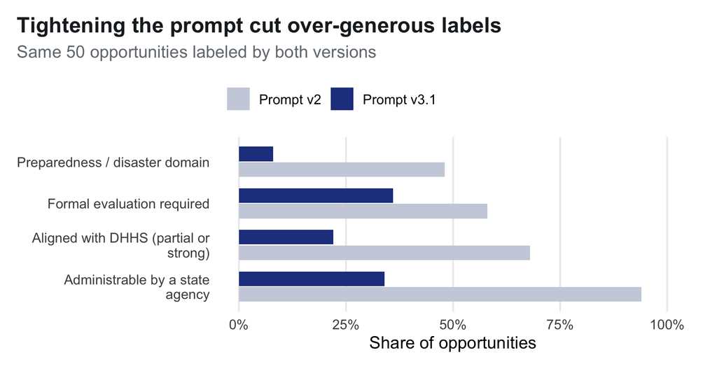

```r
if (labels_ok && file.exists(v2_path)) {
  tibble(measure = c("Aligned with DHHS (partial or strong)", "Administrable by a state agency", "Preparedness / disaster domain", "Formal evaluation required"),
         v2 = c(mean(both$llm_align_dhhs_v2 %in% c("strong", "partial")), mean(both$llm_administrable_v2), mean(both$llm_domain_v2 == "D08"), mean(both$llm_evaluation_v2)),
         v3 = c(mean(both$llm_align_dhhs_v3 %in% c("strong", "partial")), mean(both$llm_administrable_v3), mean(both$llm_domain_v3 == "D08"), mean(both$llm_evaluation_v3))) |>
    pivot_longer(c(v2, v3), names_to = "prompt", values_to = "share") |>
    mutate(prompt = if_else(prompt == "v2", "Prompt v2", "Prompt v3.1")) |>
    ggplot(aes(share, str_wrap(measure, 30), fill = prompt)) +
    geom_col(position = position_dodge(width = .75), width = .7) +
    scale_fill_manual(values = c("Prompt v2" = "#CBD1DD", "Prompt v3.1" = pal$blue), name = NULL) +
    scale_x_continuous(labels = percent, limits = c(0, 1)) +
    labs(title = "Tightening the prompt cut over-generous labels",
         subtitle = paste0("Same ", nrow(both), " opportunities labeled by both versions"), x = "Share of opportunities", y = NULL) +
    theme(legend.position = "top", legend.justification = "left", panel.grid.major.y = element_blank())
}
```

The first prompt said “yes” too easily. Making the definitions strict cut the share called “aligned with DHHS” by about two-thirds, mostly by removing wildfire, international and research programs.

**What the labeler found.** Across all labeled candidates, the capabilities it most often said an opportunity requires, and the DHHS plan rows it most often cited as the link:

**Capabilities the labeler found**

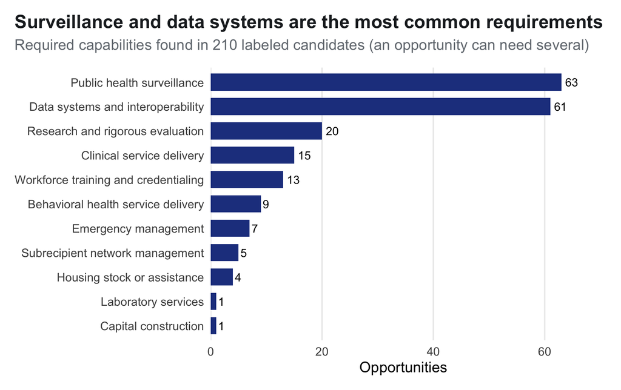

```r
if (labels_ok) {
  cap_lab <- setNames(map_chr(payload$capabilities$vocab, "label"), map_chr(payload$capabilities$vocab, "id"))
  tibble(cap = unlist(filter(labels, labeled)$llm_capabilities)) |>
    count(cap) |>
    mutate(cap = coalesce(cap_lab[cap], cap)) |>
    ggplot(aes(n, fct_reorder(cap, n))) +
    geom_col(fill = pal$blue, width = .7) +
    geom_text(aes(label = n), hjust = -.3, size = 3.3) +
    scale_x_continuous(expand = expansion(mult = c(0, .1))) +
    labs(title = "Surveillance and data systems are the most common requirements",
         subtitle = paste0("Required capabilities found in ", sum(labels$labeled), " labeled candidates (an opportunity can need several)"),
         x = "Opportunities", y = NULL) +
    theme(panel.grid.major.y = element_blank())
}
```

**DHHS plan rows the labeler cited**

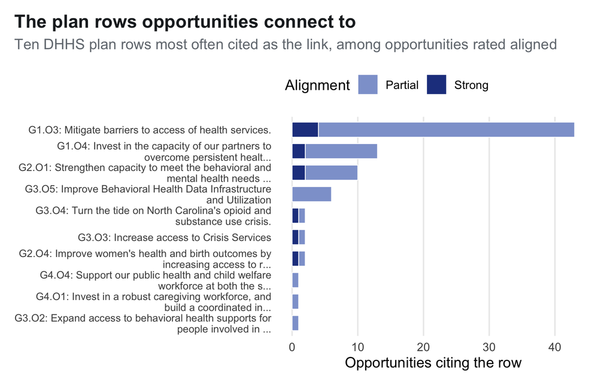

```r
if (labels_ok) {
  pr_txt <- load_priorities() |> filter(agency == "DHHS") |> select(priority_id, text)
  filter(labels, labeled, llm_align_dhhs %in% c("strong", "partial"), !is.na(llm_align_dhhs_row), llm_align_dhhs_row != "none") |>
    count(priority_id = llm_align_dhhs_row, level = str_to_sentence(llm_align_dhhs)) |>
    left_join(pr_txt, by = "priority_id") |>
    group_by(priority_id) |> mutate(total = sum(n)) |> ungroup() |>
    filter(dense_rank(desc(total)) <= 10) |>
    mutate(row = fct_reorder(str_wrap(paste0(priority_id, ": ", str_trunc(coalesce(text, ""), 70)), 55), total),
           level = factor(level, levels = c("Partial", "Strong"))) |>
    ggplot(aes(n, row, fill = level)) +
    geom_col(width = .7, color = "white", linewidth = .3) +
    scale_fill_manual(values = c("Strong" = pal$blue, "Partial" = "#8ea2d2"), name = "Alignment") +
    labs(title = "The plan rows opportunities connect to",
         subtitle = "Ten DHHS plan rows most often cited as the link, among opportunities rated aligned",
         x = "Opportunities citing the row", y = NULL) +
    theme(legend.position = "top", legend.justification = "left", panel.grid.major.y = element_blank(),
          axis.text.y = element_text(size = 8.5))
}
```

The two most common requirements, surveillance and data systems, are ones DHHS runs directly. The third, research capacity, is one it reaches only through universities, which is what defines Tier 4.

Two caveats. The v2 labels were scored against DHHS’s 2024-2026 plan before we switched to the plan the competition provides, so plan-row citations differ between versions; the alignment *levels* are still comparable. And v3 still misses some research networks that do not use activity codes like R01; the hand-label comparison below measures how often.

**The prompt.** The full labeling prompt is generated by `prompt_prefix()` and `build_prompt()` in `src/R/03_llm_label.R`; the text below is produced from that code on every render, so it is exactly what the model received. The fixed part (instructions, definitions, both strategic plans) comes first; the opportunity’s own text is appended at the end.

**Print the prompt and the output schema**

```r
pr_align <- alignable_priorities()
example <- label_set(grants) |> filter(opportunity_number == "PA-FPH-27-001")
example_nofo <- enrich$nofo$nofo_text[enrich$nofo$opportunity_number == "PA-FPH-27-001"]
prompt_text <- build_prompt(example, nofo_excerpt(if (length(example_nofo)) example_nofo else NA_character_), pr_align)
cat(str_trunc(prompt_text, 9000, side = "center", ellipsis = "\n[... middle of the example opportunity's text omitted here ...]\n"))
```

```
You label one federal funding opportunity for a grant writer inside a North Carolina state agency.
Use only the text below. If the text does not say something, answer false or "none" rather than guessing.
For each evidence field, copy a short phrase (under 25 words) verbatim from the OPPORTUNITY, ABSTRACT, ELIGIBILITY NOTES or FULL ANNOUNCEMENT EXCERPT sections, never from DEFINITIONS or the plans. Use "" if there is none.
For each alignment rationale, write one short sentence (under 30 words) in your own words naming what in the opportunity connects to the plan row.

DEFINITIONS
administrable_by_state_agency: could a North Carolina state health, human services, or veterans agency realistically be the lead applicant and run this program in North Carolina? A state agency is a public entity and a domestic government entity, so eligibility such as "any public or private entity"…
- the eligibility text excludes state governments (for example only tribes, only universities, only named or invited applicants, or states only as subrecipients);
- the work happens outside the United States;
- the award funds research by an investigator (for example R01, U01, P50, clinical trials, research centers or networks) rather than delivering or improving a program;
- the work is a function health, human services, or veterans agencies do not perform (for example law enforcement, wildland fire operations, mine cleanup, economic development, arts, agriculture).
required_capabilities: pick every capability the funded work requires the applicant to deliver:
- clinical_service_delivery: delivering medical or clinical care to patients
- behavioral_health_delivery: delivering mental health, crisis, or substance use treatment services
- long_term_care_operation: operating nursing homes or other long-term care facilities
- public_health_surveillance: disease surveillance, epidemiology, case reporting
- data_systems_interoperability: building or integrating data systems, health IT, data exchange
- research_and_rigorous_evaluation: conducting research or a rigorous (e.g. randomized or quasi-experimental) evaluation
- housing_stock_or_assistance: providing housing units, rental assistance, or shelter
- transportation_services: providing transportation to people
- workforce_training_credentialing: training, credentialing, or building a workforce pipeline
- emergency_management: emergency preparedness, response, disaster recovery, hazard mitigation
- benefits_eligibility_administration: determining eligibility for or enrolling people in public benefits
- capital_construction: construction, renovation, or acquiring buildings or land
- laboratory_services: operating laboratory testing
- subrecipient_network_management: passing funds to and monitoring subrecipients (subawards, subgrants)
program_domain (one; use "none" for anything that is not a health or human services program serving people in the United States, such as international programs, law enforcement, fire or land management, environmental cleanup, or economic development):
- D01: Behavioral health and crisis
- D02: Substance use and overdose
- D03: Maternal, infant and reproductive health
- D04: Child and family well-being
- D05: Food and nutrition security
- D06: Aging, disability and long-term care
- D07: Health access and workforce
- D08: Public health preparedness, infectious disease and disaster
- none: outside all eight domains
target_population (one): who the money ultimately serves:
- all_residents: All NC residents
- children: Children under 18
- older_adults: Adults 65 and older
- people_with_disability: People with a disability
- people_in_poverty: People below the poverty line
- uninsured: People without health insurance
- snap_households: Households receiving SNAP
- recent_births: Women who gave birth in the past year
- veterans: Veterans
- adults_mental_distress: Adults with frequent mental distress
- people_with_sud: People with a substance use disorder
- shortage_area_residents: Residents of health professional shortage areas
- hazard_exposed: Residents of high-hazard-risk counties
- system_level: System or infrastructure (no direct beneficiaries)
match_required: true if the text says the applicant must contribute non-federal funds, cost share, or matching funds, ev
[... middle of the example opportunity's text omitted here ...]
................... 37 1. Responsiveness Review ........................................................................................................ 39 2. Merit Review Criteria............................................................................................................ 40 3. Merit…
[...]
Likewise, foundational knowledge of reproductive physiology enables patients and couples to recognize early signs of dysfunction, seek timely evaluation, and participate meaningfully in care decisions. By supporting body 2 literacy education alongside evidence-based evaluation and treatment of chron…

Return JSON only.
```

**Output schema the model must match (JSON Schema)**

```
{
  "type": "object",
  "properties": {
    "administrable_by_state_agency": {
      "type": "boolean"
    },
    "administrable_evidence": {
      "type": "string"
    },
    "program_domain": {
      "type": "string",
      "enum": ["D01", "D02", "D03", "D04", "D05", "D06", "D07", "D08", "none"]
    },
    "owning_division": {
      "type": "string",
      "enum": ["DHHS: Aging", "DHHS: Child and Family Well-Being", "DHHS: Child Development and Early Education", "DHHS: Employment and Independence for People with Disabilities", "DHHS: Health Benefits (NC Medicaid)", "DHHS: Health Service Regulation", "DHHS: Mental Health, Developmental Disabiliti…
    },
    "required_capabilities": {
      "type": "array",
      "items": {
        "type": "string",
        "enum": ["clinical_service_delivery", "behavioral_health_delivery", "long_term_care_operation", "public_health_surveillance", "data_systems_interoperability", "research_and_rigorous_evaluation", "housing_stock_or_assistance", "transportation_services", "workforce_training_credentialing", "em…
      }
    },
    "requires_subrecipient_network": {
      "type": "boolean"
    },
    "evaluation_required": {
      "type": "boolean"
    },
    "is_capital_project": {
      "type": "boolean"
    },
    "needs_formal_designation": {
      "type": "boolean"
    },
    "is_renewal": {
      "type": "boolean"
    },
    "match_required": {
```

[output cut: 34 more lines]

```
          "enum": ["strong", "partial", "none"]
        },
        "plan_row": {
          "type": "string",
          "enum": ["G1", "G1.O1", "G1.O1.Q1", "G1.O1.Q2", "G1.O1.Q3", "G1.O2", "G1.O2.Q1", "G1.O2.Q2", "G1.O2.Q3", "G1.O3", "G1.O3.Q1", "G2", "G2.O1", "G2.O1.Q1", "G2.O1.Q2", "G2.O2", "G2.O2.Q1", "G2.O2.Q2", "G2.O2.Q3", "G2.O2.Q4", "G3", "G3.O1", "G3.O1.Q1", "G3.O1.Q2", "none"]
        },
        "rationale": {
          "type": "string"
        }
      },
      "required": ["level", "plan_row", "rationale"]
    }
  },
  "required": ["administrable_by_state_agency", "administrable_evidence", "program_domain", "owning_division", "required_capabilities", "requires_subrecipient_network", "evaluation_required", "is_capital_project", "needs_formal_designation", "is_renewal", "match_required", "match_pct_stated", "match…
}
```

**Validation against hand labels.** Sixty candidates were drawn at random, stratified by status, issuing agency family, and whether a full announcement exists, and labeled by team members who had not seen the model’s answers.

**Accuracy, precision and recall**

```r
if (is.null(validation)) {
  cat('<div class="pending">Waiting for <code>data/manual/handlabels_60.csv</code>. The comparison runs automatically once it exists.</div>')
} else {
  print(htmltools::tagList(
    dt(validation$summary |> mutate(accuracy = pct_fmt(accuracy)), dom = "t", pageLength = 20),
    dt(validation$capabilities |> mutate(across(c(precision, recall), pct_fmt)), dom = "t"),
    dt(validation$by_class |> mutate(across(c(precision, recall), ~ ifelse(is.na(.x), "n/a", pct_fmt(.x)))), pageLength = 15)
  ))
}
```

| field | n | accuracy | note |
| --- | --- | --- | --- |
| administrable | 60 | 67% |  |
| domain | 59 | 46% |  |
| DHHS alignment | 59 | 59% |  |
| DMVA alignment | 58 | 95% |  |
| match required | 58 | 93% |  |
| subrecipients | 18 | 50% |  |
| evaluation | 18 | 44% |  |
| capital project | 18 | 94% |  |
| designation | 18 | 94% |  |
| renewal | 18 | 67% |  |

[output cut: 1 more lines]

| field | n | precision | recall |
| --- | --- | --- | --- |
| required capabilities (micro) | 60 | 53% | 27% |

| field | class | support | precision | recall |
| --- | --- | --- | --- | --- |
| administrable | FALSE | 41 | 84% | 63% |
| administrable | TRUE | 19 | 48% | 74% |
| domain | d01 | 5 | 25% | 20% |
| domain | d02 | 2 | n/a | 0% |
| domain | d03 | 3 | 50% | 33% |
| domain | d04 | 5 | 50% | 40% |
| domain | d05 | 2 | n/a | 0% |
| domain | d06 | 1 | 0% | 0% |
| domain | d07 | 4 | 0% | 0% |
| domain | d08 | 10 | 33% | 20% |

[output cut: 20 more lines]

**Agreement with the team, by field**

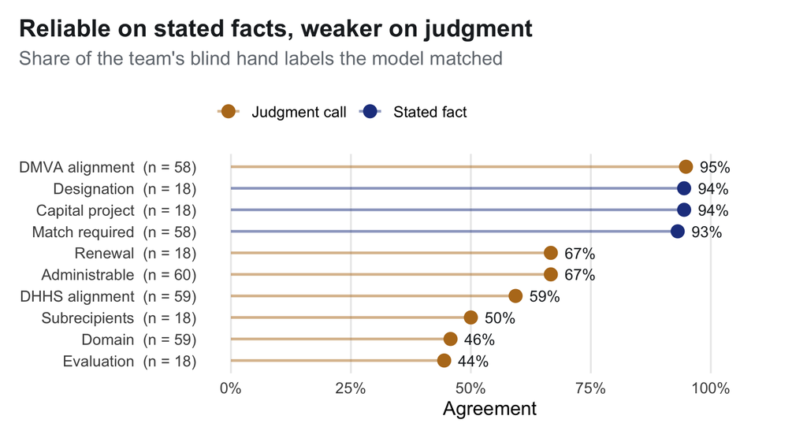

```r
if (!is.null(validation)) {
  facts_f <- c("match required", "capital project", "designation")
  validation$summary |> filter(!is.na(accuracy)) |>
    mutate(kind = if_else(field %in% facts_f, "Stated fact", "Judgment call"),
           field = str_replace_all(str_to_sentence(field), c("Dmva" = "DMVA", "Dhhs" = "DHHS")),
           field = fct_reorder(paste0(field, "  (n = ", n, ")"), accuracy)) |>
    ggplot(aes(accuracy, field, color = kind)) +
    geom_segment(aes(x = 0, xend = accuracy, yend = field), linewidth = .8, alpha = .5) +
    geom_point(size = 3.4) +
    geom_text(aes(label = pct_fmt(accuracy)), hjust = -.45, size = 3.4, color = pal$dark) +
    scale_color_manual(values = c("Stated fact" = pal$blue, "Judgment call" = pal$orange), name = NULL) +
    scale_x_continuous(labels = percent, limits = c(0, 1.08), breaks = seq(0, 1, .25)) +
    labs(title = "Reliable on stated facts, weaker on judgment",
         subtitle = "Share of the team's blind hand labels the model matched",
         x = "Agreement", y = NULL) +
    theme(legend.position = "top", legend.justification = "left", panel.grid.major.y = element_blank())
}
```

The facts that put an opportunity in Tier 3 (match, construction, designation) agree over 90% of the time. Judgment calls (could a state lead it, how well it fits the plan) agree about half to two-thirds of the time, so the tool shows the model’s evidence on every card. DMVA alignment scores high only because almost nothing in the file concerns veterans, so “none” is usually right.

**Where the model and the team disagree**

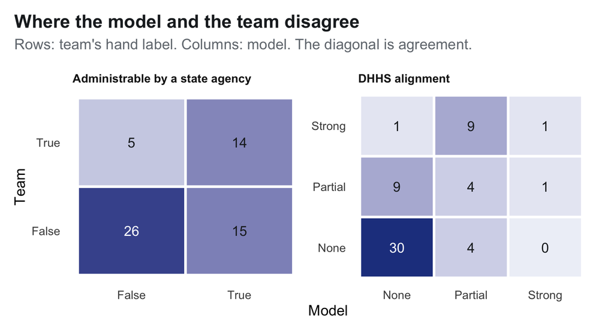

```r
if (!is.null(validation)) {
  map_dfr(c("administrable", "DHHS alignment"), function(f) {
    as.data.frame(validation$confusion[[f]], stringsAsFactors = FALSE) |>
      mutate(field = if (f == "administrable") "Administrable by a state agency" else "DHHS alignment")
  }) |>
    mutate(across(c(human, model), ~ str_to_sentence(.x))) |>
    group_by(field) |> mutate(share = Freq / sum(Freq)) |> ungroup() |>
    ggplot(aes(model, human, fill = Freq)) +
    geom_tile(color = "white", linewidth = 1) +
    geom_text(aes(label = Freq, color = Freq > max(Freq) / 2), size = 4, show.legend = FALSE) +
    scale_color_manual(values = c(`TRUE` = "white", `FALSE` = pal$dark)) +
    scale_fill_gradient(low = "#EEF1F8", high = pal$blue, guide = "none") +
    facet_wrap(~ field, scales = "free") +
    labs(title = "Where the model and the team disagree",
         subtitle = "Rows: team's hand label. Columns: model. The diagonal is agreement.", x = "Model", y = "Team") +
    theme(panel.grid = element_blank(), strip.text = element_text(face = "bold", hjust = 0))
}
```

**Where the model disagreed with the humans**

```r
if (!is.null(validation) && nrow(validation$disagreements) > 0) {
  hl_notes <- handlabels |> select(opportunity_number, team_notes = notes)
  validation$disagreements |>
    filter(field %in% c("administrable", "DHHS alignment", "match required", "domain")) |>
    left_join(select(grants, opportunity_number, opportunity_title, summary_text), by = "opportunity_number") |>
    left_join(select(labels, opportunity_number, llm_administrable_evidence, llm_align_dhhs_why, llm_match_evidence), by = "opportunity_number") |>
    left_join(hl_notes, by = "opportunity_number") |>
    transmute(field, opportunity = opportunity_title, team = human, model,
              `model's own evidence or reason` = case_when(
                field == "administrable" ~ llm_administrable_evidence,
                field == "DHHS alignment" ~ llm_align_dhhs_why,
                field == "match required" ~ llm_match_evidence, TRUE ~ ""),
              `team notes` = coalesce(team_notes, ""),
              abstract = str_trunc(summary_text, 350)) |>
    dt(pageLength = 6) |> print()
} else {
  cat('<div class="pending">Disagreement examples appear here once hand labels exist. We quote real errors only.</div>')
}
```

**Caveats on the comparison**

```r
if (!is.null(validation)) {
  dev <- readr::read_csv(file.path(DIR_MANUAL, "prompt_dev_cases.csv"), show_col_types = FALSE)
  dev_ids <- grants$opportunity_number[map_lgl(grants$opportunity_title, function(t) any(str_detect(t, fixed(dev$title_contains))))]
  overlap <- intersect(dev_ids, handlabels$opportunity_number)
  cat(sprintf("- **Tuning overlap.** Prompt v3.1 was checked against %d development cases chosen before the hand labels existed. %d of them are also in the 60-row hand-label sample%s. Their agreement could be slightly flattering; the rest of the sample was never used for tuning.\n",
              nrow(dev), length(overlap), if (length(overlap)) paste0(" (", paste(overlap, collapse = ", "), ")") else ""))
  if (length(validation$not_comparable))
    cat(sprintf("- **Not comparable:** %s. The team described these in free text rather than choosing from the model's fixed categories, so agreement cannot be scored automatically.\n",
                paste(validation$not_comparable, collapse = ", ")))
  if (nrow(validation$out_of_taxonomy))
    cat(sprintf("- **Outside the taxonomy:** %d hand labels use a domain that is not one of the eight (%s). The model cannot choose it, so these count as disagreements.\n",
                nrow(validation$out_of_taxonomy), paste(unique(validation$out_of_taxonomy$human), collapse = "; ")))
}
```

- **Tuning overlap.** Prompt v3.1 was checked against 16 development cases chosen before the hand labels existed. 2 of them are also in the 60-row hand-label sample (HRSA-27-057, VA-GRANTS-112508-002). Their agreement could be slightly flattering; the rest of the sample was never used for tuning.
- **Not comparable:** target population. The team described these in free text rather than choosing from the model’s fixed categories, so agreement cannot be scored automatically.
- **Outside the taxonomy:** 3 hand labels use a domain that is not one of the eight (d09). The model cannot choose it, so these count as disagreements.

**Check the match disagreements against the source text**

```r
if (!is.null(validation)) {
  md <- validation$disagreements |> filter(field == "match required") |>
    left_join(select(grants, opportunity_number, is_cost_sharing, summary_text), by = "opportunity_number") |>
    left_join(select(labels, opportunity_number, llm_match_evidence), by = "opportunity_number") |>
    left_join(select(enrich$nofo, opportunity_number, nofo_text), by = "opportunity_number") |>
    mutate(quote_in_text = map2_lgl(llm_match_evidence, paste(summary_text, coalesce(nofo_text, "")), function(ev, hay)
             nzchar(coalesce(ev, "")) && str_detect(str_squish(str_to_lower(hay)), fixed(str_sub(str_squish(str_to_lower(ev)), 1, 60)))))
  backed <- sum(md$model == "TRUE" & md$is_cost_sharing & md$quote_in_text)
  cat(sprintf("**Not every disagreement is a model error.** Of the %d disagreements on whether match is required, %d have the model saying *required* where the structured data's own cost-sharing flag also says required and the model's quote appears word for word in the announcement (for example: \"%s\"). Those are hand-label slips, not model errors; we report the raw agreement and leave the team's labels as written.\n",
              nrow(md), backed, if (backed) md$llm_match_evidence[which(md$model == "TRUE" & md$is_cost_sharing & md$quote_in_text)[1]] else ""))
}
```

**Not every disagreement is a model error.** Of the 4 disagreements on whether match is required, 4 have the model saying *required* where the structured data’s own cost-sharing flag also says required and the model’s quote appears word for word in the announcement (for example: “The Recipient is responsible for a cost-sharing contribution Requirement totaling 15% of the Federal Award.”). Those are hand-label slips, not model errors; we report the raw agreement and leave the team’s labels as written.

One catch that needs no hand label: the Title X Family Planning Services opportunity is marked as having no cost sharing in the structured data, yet the labeler quoted its full announcement: “projects must include financial support from sources other than Title X.” The tool treats it as a match requirement.

# 13. County need layers

Almost every opportunity here is statewide, so joining county data straight to opportunities would give a near-constant column. Instead, county data describe **program domains**: each domain’s need index is a county’s average percentile rank across that domain’s indicators, and an opportunity inherits its domain’s map. The tool shows these with a boundary overlay for counties, congressional districts, census tracts, and places.

**Need index by domain**

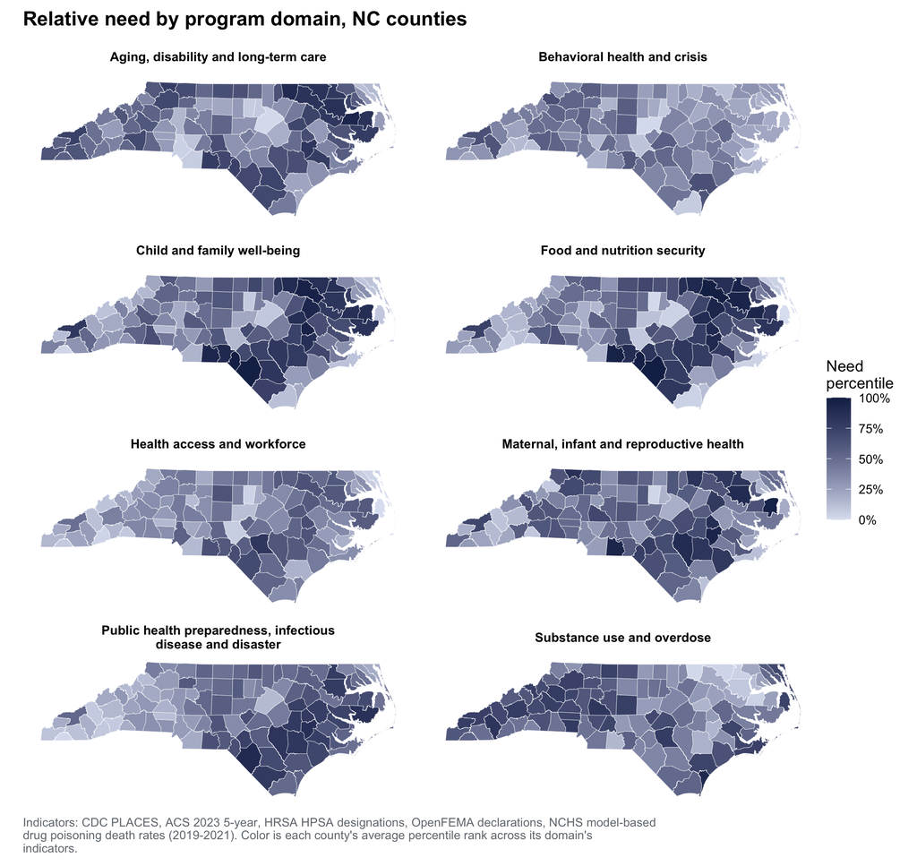

```r
ci <- build_county_indicators()
need <- build_domain_need(ci)
counties <- readRDS(file.path(DIR_CACHE_GEO, "nc_county_2023.rds"))
need_long <- imap_dfr(need, function(d, id) if (!isTRUE(d$available)) NULL else
  tibble(fips = names(d$index), index = unlist(d$index), domain = DOMAINS[[id]]))
counties |> select(GEOID) |> inner_join(need_long, by = c("GEOID" = "fips")) |>
  ggplot() + geom_sf(aes(fill = index), color = "white", linewidth = .1) +
  scale_fill_gradient(low = "#dde3f1", high = "#172a55", labels = percent, name = "Need\npercentile") +
  facet_wrap(~ str_wrap(domain, 40), ncol = 2) +
  labs(title = "Relative need by program domain, NC counties",
       caption = str_wrap(paste0("Indicators: CDC PLACES, ACS 2023 5-year, HRSA HPSA designations, OpenFEMA declarations, NCHS model-based drug poisoning death rates (",
                        min(OVERDOSE_YEARS), "-", max(OVERDOSE_YEARS), "). Color is each county's average percentile rank across its domain's indicators."), 110)) +
  theme_void() +
  theme(strip.text = element_text(face = "bold", size = 9, margin = margin(b = 4)),
        plot.title = element_text(face = "bold", size = 14, margin = margin(b = 10)),
        plot.title.position = "plot", plot.caption.position = "plot",
        plot.caption = element_text(hjust = 0, color = pal$gray, size = 8.5, margin = margin(t = 10)),
        panel.spacing = unit(10, "pt"), plot.margin = margin(8, 8, 8, 8))
```

Need is not one map. Poverty-driven domains (food, children, maternal health) concentrate in the east and southeast; overdose concentrates in the mountains; preparedness follows the hurricane coast.

**Every indicator behind those maps.** Each source is shown on its own, as a percentile rank across the 100 counties (darker = higher need), so a reader can see which dataset drives each domain.

**Each county indicator mapped**

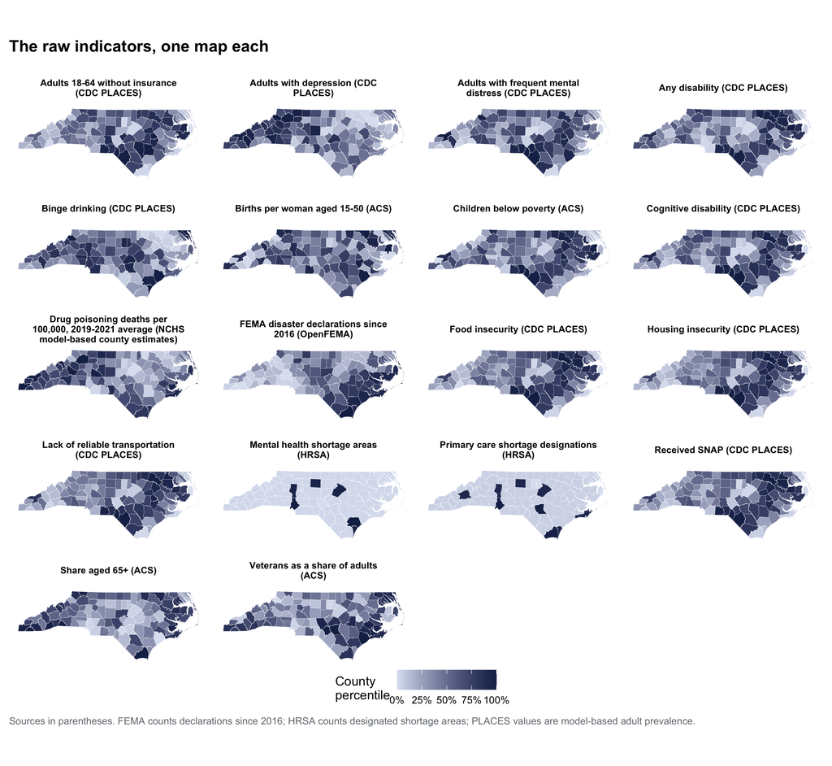

```r
ind <- imap_dfr(domain_indicators(), ~ tibble(var = names(.x), label = unname(.x))) |> distinct(var, .keep_all = TRUE)
ind <- bind_rows(ind, tibble(var = "veteran_share", label = "Veterans as a share of adults (ACS)"))
counties |> select(GEOID) |>
  inner_join(ci |> select(fips, any_of(ind$var)) |>
               pivot_longer(-fips, names_to = "var", values_to = "value") |>
               group_by(var) |> mutate(pct = percent_rank(value)) |> ungroup(),
             by = c("GEOID" = "fips")) |>
  left_join(ind, by = "var") |>
  mutate(label = str_wrap(label, 34)) |>
  ggplot() + geom_sf(aes(fill = pct), color = "white", linewidth = .05) +
  scale_fill_gradient(low = "#dde3f1", high = "#172a55", labels = percent, name = "County\npercentile", na.value = "#eeeeee") +
  facet_wrap(~ label, ncol = 4) +
  labs(title = "The raw indicators, one map each",
       caption = "Sources in parentheses. FEMA counts declarations since 2016; HRSA counts designated shortage areas; PLACES values are model-based adult prevalence.") +
  theme_void() +
  theme(strip.text = element_text(size = 8, face = "bold", margin = margin(b = 3, t = 6)),
        plot.title = element_text(face = "bold", size = 14, margin = margin(b = 10)),
        plot.title.position = "plot", plot.caption.position = "plot",
        plot.caption = element_text(hjust = 0, color = pal$gray, size = 8.5, margin = margin(t = 10)),
        legend.position = "bottom", plot.margin = margin(8, 8, 8, 8))
```

**Indicators behind each domain**

```r
imap_dfr(domain_indicators(), ~ tibble(domain = DOMAINS[[.y]], indicator = unname(.x))) |> dt(pageLength = 20)
```

| domain | indicator |
| --- | --- |
| Behavioral health and crisis | Adults with frequent mental distress (CDC PLACES) |
| Behavioral health and crisis | Adults with depression (CDC PLACES) |
| Behavioral health and crisis | Mental health shortage areas (HRSA) |
| Substance use and overdose | Drug poisoning deaths per 100,000, 2019-2021 average (NCHS model-based county estimates) |
| Substance use and overdose | Binge drinking (CDC PLACES) |
| Maternal, infant and reproductive health | Births per woman aged 15-50 (ACS) |
| Maternal, infant and reproductive health | Adults 18-64 without insurance (CDC PLACES) |
| Child and family well-being | Children below poverty (ACS) |
| Child and family well-being | Housing insecurity (CDC PLACES) |
| Food and nutrition security | Food insecurity (CDC PLACES) |

[output cut: 9 more lines]

**Drug poisoning death rates by county**

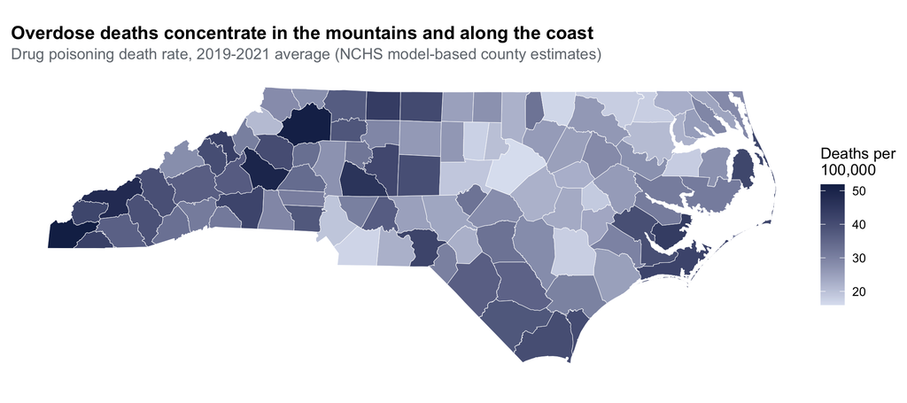

```r
counties |> select(GEOID) |> left_join(select(ci, fips, overdose_rate), by = c("GEOID" = "fips")) |>
  ggplot() + geom_sf(aes(fill = overdose_rate), color = "white", linewidth = .15) +
  scale_fill_gradient(low = "#dde3f1", high = "#172a55", name = "Deaths per\n100,000") +
  labs(title = "Overdose deaths concentrate in the mountains and along the coast",
       subtitle = paste0("Drug poisoning death rate, ", min(OVERDOSE_YEARS), "-", max(OVERDOSE_YEARS), " average (NCHS model-based county estimates)")) +
  theme_void() +
  theme(plot.title = element_text(face = "bold", size = 13, margin = margin(b = 4)), plot.subtitle = element_text(color = pal$gray, margin = margin(b = 8)),
        plot.title.position = "plot", plot.margin = margin(8, 8, 8, 8))
```

The western mountain counties and parts of the southeast coast have the highest overdose death rates, a different set of counties from where poverty-driven need is highest.

**Do the need layers point to the same counties?**

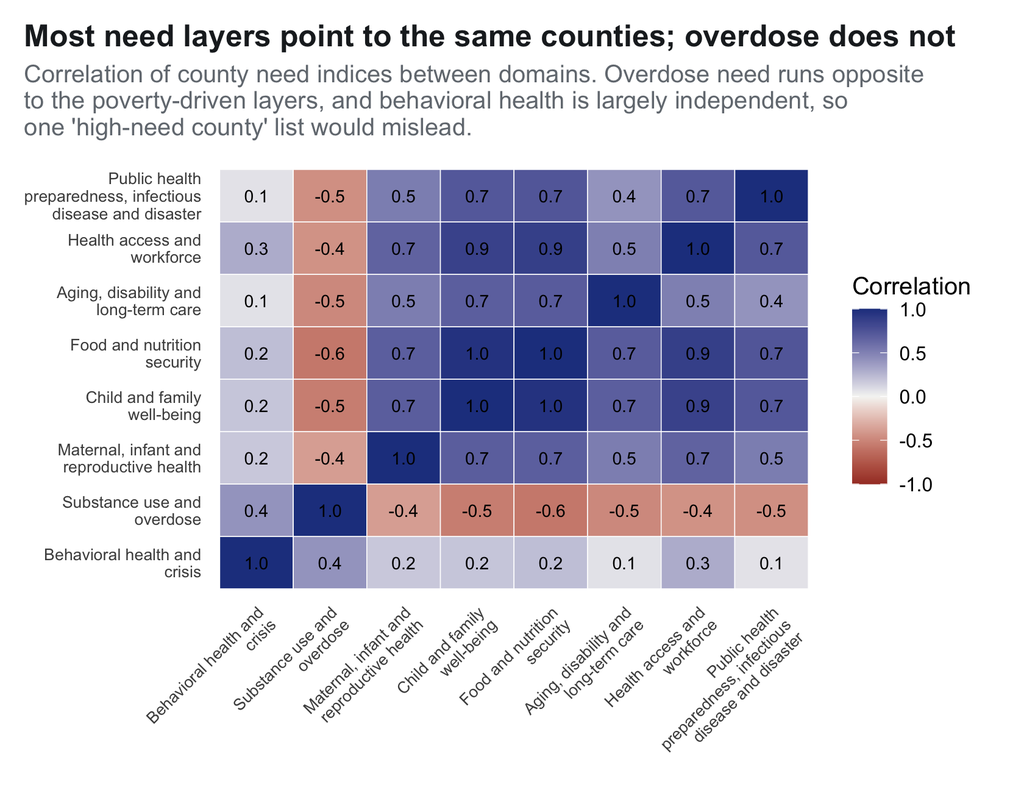

```r
nm <- need_long |> mutate(domain = str_wrap(domain, 24)) |> pivot_wider(names_from = domain, values_from = index)
cm <- cor(select(nm, -fips), use = "pairwise.complete.obs")
as.data.frame(as.table(cm)) |>
  ggplot(aes(Var1, Var2, fill = Freq)) +
  geom_tile(color = "white") +
  geom_text(aes(label = sprintf("%.1f", Freq)), size = 3) +
  scale_fill_gradient2(low = pal$red, mid = "#f5f5f3", high = pal$blue, midpoint = 0, limits = c(-1, 1), name = "Correlation") +
  labs(title = "Most need layers point to the same counties; overdose does not",
       subtitle = str_wrap("Correlation of county need indices between domains. Overdose need runs opposite to the poverty-driven layers, and behavioral health is largely independent, so one 'high-need county' list would mislead.", 80),
       x = NULL, y = NULL) +
  theme(axis.text.x = element_text(angle = 45, hjust = 1, size = 8), axis.text.y = element_text(size = 8), panel.grid = element_blank())
```

This is why the tool maps need per domain instead of ranking “high-need counties” once: a substance-use grant and a nutrition grant point a writer to different parts of the state.

# 14. The tool

The same file judges would open by double-click, embedded here. It recomputes every tier in the browser as settings change.

**Using the tool.** A writer can describe their situation in plain English, for example “one month, match with approval, awards of at least $1 million, reach the most people”. The tool then sets: - runway, match authority and staff; - minimum award; - program priorities; - what matters most for the impact score.

Each setting it changes appears as a chip that can be undone. Example buttons apply ready-made scenarios in one click, presets set whole personas, and a “Larger text” button enlarges everything for a projector.

**Who an opportunity reaches.** Each opportunity’s detail panel has a “Who this reaches in NC” section, and the map has a matching layer. They show: - where the population it serves lives: the counties with the most people and with the highest share of residents; - the split between rural, suburban and urban counties (NC Rural Center density definition); - counts by congressional district (ACS 2019-2023, 118th Congress districts).

This describes where people live, not where a statewide award would be spent. It is most informative for the opportunities labeled with a specific group (children, veterans, adults in mental distress, recent births and others). The labeler marked most opportunities as serving all residents or as system-level work with no direct beneficiaries.

**Embed outs/grant-triage-tool.html**

```r
if (file.exists(TOOL_HTML_OUT)) {
  tags$iframe(srcdoc = paste(readLines(TOOL_HTML_OUT, warn = FALSE, encoding = "UTF-8"), collapse = "\n"),
              style = "width:100%; height:1100px; border:1px solid #E4E7EC; border-radius:8px;",
              title = "NC Grants Explorer tool")
} else {
  HTML('<div class="pending">Build the tool first: <code>Rscript src/tool/build_tool.R</code></div>')
}
```

[interactive chart not shown]

## Top results

The competition asks for a top results list with a one-line rationale per opportunity tied to the match criteria. This is it: every opportunity in Tiers 1-3 of the tool’s opening scenario (the interview persona: about a month of runway, supervisor approves match, one FTE, forecasts included), for DHHS and DMVA, ordered by tier and then by impact score with equal weights. Each line walks the five criteria in order: can we apply, do we have the capabilities, is there runway, what is the award, is the match survivable. Tier 4 (partner-led research) is excluded here; it is in the tool. Also saved as `outs/top_results.xlsx`.

**Top results list (computed by tiering.js)**

```r
top_results <- bind_rows(build_top_results(payload, "DHHS"), build_top_results(payload, "DMVA"))
top_results |>
  transmute(agency, tier, impact = impact_score, opportunity = title, deadline, rationale) |>
  dt(pageLength = 25)
```

| agency | tier | impact | opportunity | deadline | rationale |
| --- | --- | --- | --- | --- | --- |
| DHHS | 1 | 71 | Integrated Viral Hepatitis Surveillance, Testing, Treatment, and Prevention Programs for Health Departments (IVH-STTP) | 2027-02-16 | state agency can apply, forecast (not yet posted) · required capabilities in-house or contracted · 139 days to deadline · about $7.5M per award (estimated: total ÷ expected awards) · no cost share → T… |
| DHHS | 1 | 66 | Fiscal Year (FY) Service Area Competition (SAC) | 2026-12-30 | state agency can apply, forecast (not yet posted) · required capabilities in-house or contracted · 91 days to deadline · up to $22.0M (Grants.gov ceiling) · no cost share → Tier 1: writer can act |
| DHHS | 1 | 65 | Fiscal Year (FY) 2027 Service Area Competition (SAC) | 2026-12-30 | state agency can apply, forecast (not yet posted) · required capabilities in-house or contracted · 91 days to deadline · up to $19.2M (Grants.gov ceiling) · no cost share → Tier 1: writer can act |
| DHHS | 1 | 65 | Centers of Excellence in Healthcare Quality and Safety | 2027-01-04 | state agency can apply, forecast (not yet posted) · required capabilities in-house or contracted · 96 days to deadline · up to $22.0M (Grants.gov ceiling) · no cost share → Tier 1: writer can act |
| DHHS | 1 | 64 | Fiscal Year (FY) 2027 Service Area Competition (SAC) | 2027-01-08 | state agency can apply, forecast (not yet posted) · required capabilities in-house or contracted · 100 days to deadline · up to $15.3M (Grants.gov ceiling) · no cost share → Tier 1: writer can act |
| DHHS | 1 | 62 | Ryan White HIV/AIDS Program Part B States/Territories Supplemental Grant Program | 2027-03-15 | state agency can apply, forecast (not yet posted) · required capabilities in-house or contracted · 166 days to deadline · up to $9.0M (Grants.gov ceiling) · no cost share → Tier 1: writer can act |
| DHHS | 1 | 61 | Controlling and Preventing STIs in US Health Departments (CAP-STIs) | 2027-01-11 | state agency can apply, forecast (not yet posted) · required capabilities in-house or contracted · 103 days to deadline · about $8.5M per award (estimated: total ÷ expected awards) · no cost share → T… |
| DHHS | 1 | 61 | Strengthening Services to Prevent the Infectious Disease Consequences of Drug Use | 2027-05-24 | state agency can apply, forecast (not yet posted) · required capabilities in-house or contracted · 236 days to deadline · about $41.2M per award (estimated: total ÷ expected awards) · no cost share → … |
| DHHS | 1 | 57 | HIV Care Grant Program - Part B States/Territories Formula and AIDS Drug Assistance Program Formula and AIDS Drug Assistance Program Supplemental Awards | 2026-12-31 | state agency can apply, forecast (not yet posted) · required capabilities in-house or contracted · 92 days to deadline · about $21.7M per award (estimated: total ÷ expected awards) · no cost share → T… |
| DHHS | 1 | 56 | AIDS Drug Assistance Program (ADAP) Emergency Relief Funds (ERF) | 2026-11-02 | state agency can apply, forecast (not yet posted) · required capabilities in-house or contracted · 33 days to deadline · up to $10.0M (Grants.gov ceiling) · no cost share → Tier 1: writer can act |

[output cut: 47 more lines]

54 opportunities make the DHHS list: 27 the writer can start, 24 that need a supervisor or division, and 3 that need the secretary or legislature. 46 of them are forecasts: the posted pipeline for a DHHS writer on September 30 is thin, and most of the actionable work is preparing for what is about to post.

## Reach and intensity

“People reached” in the impact score comes from the population the labeler says an opportunity serves, counted for North Carolina from the ACS and CDC PLACES:

**Size of each target population in NC**

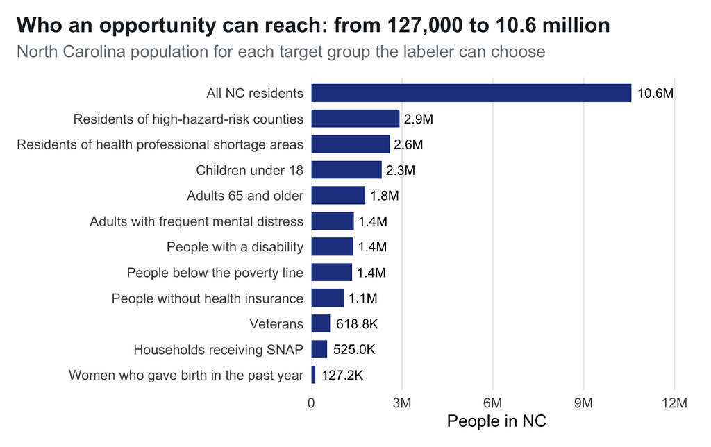

```r
map_dfr(payload$populations, ~ tibble(label = .x$label, n = .x$n %||% NA_real_, source = .x$source %||% "")) |>
  filter(!is.na(n), n > 0) |>
  mutate(label = fct_reorder(label, n)) |>
  ggplot(aes(n, label)) +
  geom_col(fill = pal$blue, width = .7) +
  geom_text(aes(label = label_number(scale_cut = cut_short_scale(), accuracy = .1)(n)), hjust = -.15, size = 3.3) +
  scale_x_continuous(labels = label_number(scale_cut = cut_short_scale()), expand = expansion(mult = c(0, .16))) +
  labs(title = "Who an opportunity can reach: from 127,000 to 10.6 million",
       subtitle = "North Carolina population for each target group the labeler can choose",
       x = "People in NC", y = NULL) +
  theme(panel.grid.major.y = element_blank())
```

**People served vs dollars per person, opening scenario**

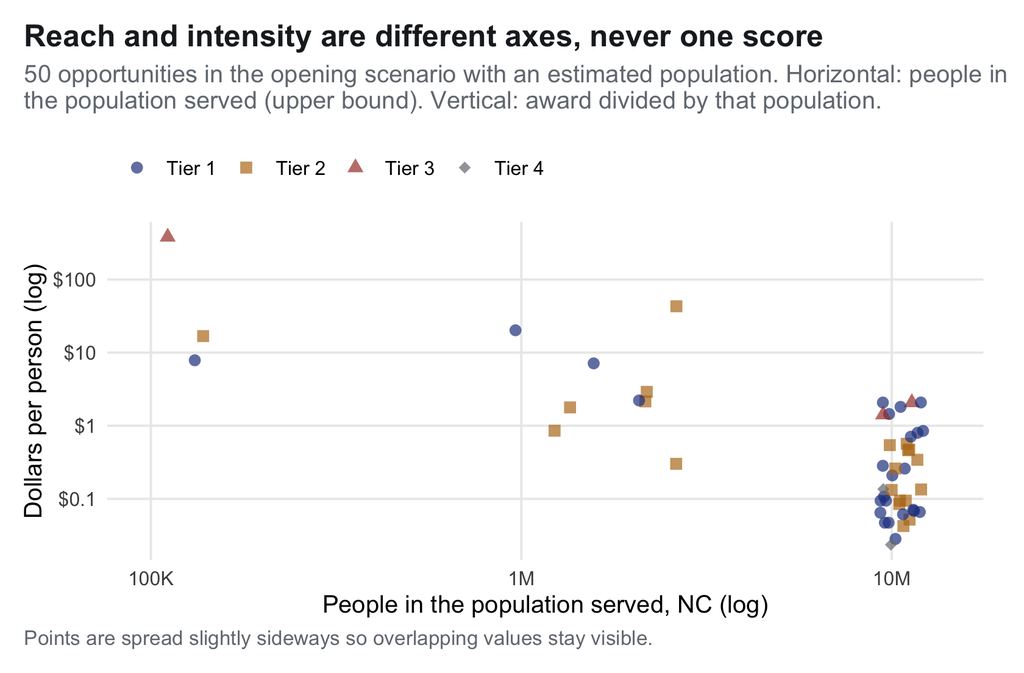

```r
rv <- opening |> filter(placement == "pile") |>
  mutate(o = map(opportunity_number, function(n) keep(opps, ~ .x$number == n)[[1]]),
         people = map_dbl(o, ~ .x$people_est %||% NA_real_),
         award = map_dbl(o, ~ .x$award_estimate_usd %||% NA_real_),
         pop = map_chr(o, ~ .x$target_population %||% NA_character_)) |>
  filter(!is.na(people), !is.na(award), people > 0) |>
  mutate(per_person = award / people, tier = factor(paste("Tier", tier)))
ggplot(rv, aes(people, per_person, color = tier, shape = tier)) +
  geom_point(size = 2.4, alpha = .7, position = position_jitter(width = .06, height = 0, seed = SEED)) +
  scale_x_log10(labels = label_number(scale_cut = cut_short_scale()), expand = expansion(mult = .08)) +
  scale_y_log10(labels = label_dollar(accuracy = .001, drop0trailing = TRUE)) +
  scale_color_manual(values = c("Tier 1" = pal$tier1, "Tier 2" = pal$tier2, "Tier 3" = pal$tier3, "Tier 4" = pal$gray), name = NULL) +
  scale_shape_manual(values = c("Tier 1" = 16, "Tier 2" = 15, "Tier 3" = 17, "Tier 4" = 18), name = NULL) +
  labs(title = "Reach and intensity are different axes, never one score",
       subtitle = str_wrap(paste0(nrow(rv), " opportunities in the opening scenario with an estimated population. Horizontal: people in the population served (upper bound). Vertical: award divided by that population."), 95),
       x = "People in the population served, NC (log)", y = "Dollars per person (log)",
       caption = "Points are spread slightly sideways so overlapping values stay visible.") +
  theme(legend.position = "top", legend.justification = "left")
```

Opportunities serving the same population share a horizontal position, so they stack in columns; the estimate is only as good as the population the labeler chose, which the team could not score automatically (section 12).

**Where each population lives.** The same counts, split by the NC Rural Center’s density grouping (rural = 250 people per square mile or fewer; urban = more than 750) and by congressional district:

**Rural, suburban and urban share of each target population**

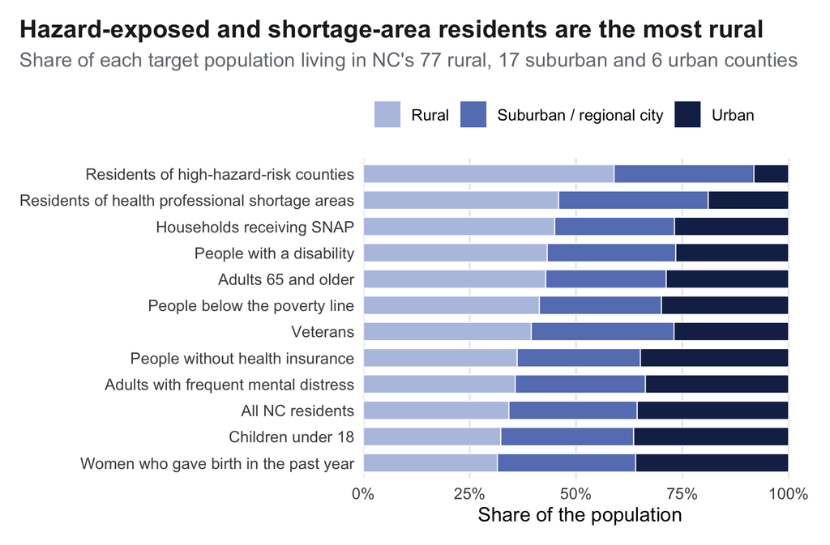

```r
rur <- unlist(payload$community$county_rurality)
rur_lab <- c(rural = "Rural", suburban = "Suburban / regional city", urban = "Urban")
imap_dfr(payload$populations, function(p, id) if (is.null(p$county) || !length(p$county)) NULL else
  tibble(label = p$label, fips = names(p$county), n = unlist(p$county))) |>
  mutate(rurality = factor(rur_lab[rur[fips]], levels = rev(rur_lab))) |>
  count(label, rurality, wt = n) |>
  group_by(label) |> mutate(share = n / sum(n), rural_share = sum(share[rurality == "Rural"])) |> ungroup() |>
  ggplot(aes(share, fct_reorder(label, rural_share), fill = rurality)) +
  geom_col(width = .7, color = "white", linewidth = .3) +
  scale_fill_manual(values = c("Rural" = "#b7c4e3", "Suburban / regional city" = "#6680bf", "Urban" = "#172a55"),
                    breaks = unname(rur_lab), name = NULL) +
  scale_x_continuous(labels = percent, expand = expansion(mult = c(0, .02))) +
  labs(title = "Hazard-exposed and shortage-area residents are the most rural",
       subtitle = paste0("Share of each target population living in NC's ", sum(rur == "rural"), " rural, ",
                         sum(rur == "suburban"), " suburban and ", sum(rur == "urban"), " urban counties"),
       x = "Share of the population", y = NULL) +
  theme(legend.position = "top", legend.justification = "left", panel.grid.major.y = element_blank())
```

**Target populations by congressional district**

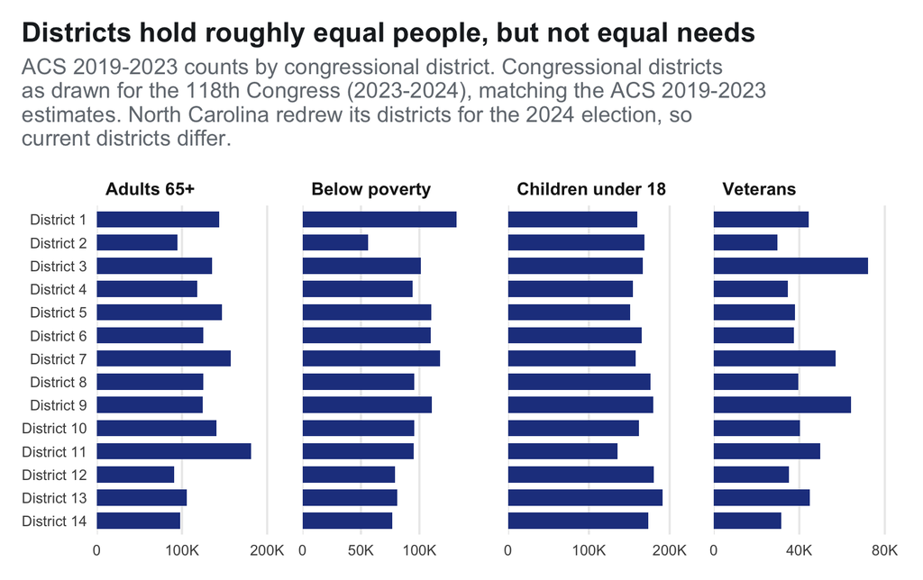

```r
dn <- unlist(payload$community$district_names)
imap_dfr(payload$populations, function(p, id) if (is.null(p$district) || id == "all_residents") NULL else
  tibble(label = p$label, geoid = names(p$district), n = unlist(p$district))) |>
  filter(label %in% c("Children under 18", "Adults 65 and older", "Veterans", "People below the poverty line")) |>
  mutate(label = recode(label, "People below the poverty line" = "Below poverty", "Adults 65 and older" = "Adults 65+")) |>
  mutate(district = factor(str_remove(dn[geoid], "Congressional "), levels = str_remove(dn[order(as.integer(names(dn)))], "Congressional "))) |>
  ggplot(aes(n, fct_rev(district))) +
  geom_col(fill = pal$blue, width = .7) +
  facet_wrap(~ label, nrow = 1, scales = "free_x") +
  scale_x_continuous(labels = label_number(scale_cut = cut_short_scale()), breaks = scales::breaks_extended(3), expand = expansion(mult = c(0, .12))) +
  labs(title = "Districts hold roughly equal people, but not equal needs",
       subtitle = str_wrap(paste0("ACS 2019-2023 counts by congressional district. ", payload$community$district_note), 78),
       x = NULL, y = NULL) +
  theme(strip.text = element_text(face = "bold", hjust = 0), panel.grid.major.y = element_blank(), axis.text.y = element_text(size = 8),
        axis.text.x = element_text(size = 8), panel.spacing.x = unit(18, "pt"))
```

Each district has about 750,000 residents, yet veterans are concentrated in districts 3 and 9 and older adults in district 11. A grant for one population reaches very different parts of the state than a grant for another.

Large statewide programs spread cents per person across millions; a few small programs put $10-100 per person into a narrow group. The tool lets the writer choose which matters more instead of blending the two.

# 15. Evaluation

## What landed in the piles

**Opening-scenario results for hand spot-checking**

```r
opening |> filter(placement == "pile", tier <= 3) |>
  left_join(labels %||% tibble(opportunity_number = character(), labeled = logical(), has_nofo = logical()), by = "opportunity_number") |>
  transmute(tier, opportunity = opportunity_title,
            `labeled by model` = coalesce(labeled, FALSE),
            `full announcement read` = coalesce(has_nofo, FALSE), reason = tier_reason) |>
  arrange(tier) |> dt()
```

| tier | opportunity | labeled by model | full announcement read | reason |
| --- | --- | --- | --- | --- |
| 1 | Fiscal Year (FY) 2027 Service Area Competition (SAC) | True | False | No escalation: required capabilities are in-house or contracted, no cost share, about 0.25 FTE fits your staff |
| 1 | Strengthening Services to Prevent the Infectious Disease Consequences of Drug Use | True | False | No escalation: required capabilities are in-house or contracted, no cost share, about 0.5 FTE fits your staff |
| 1 | Centers of Excellence in Healthcare Quality and Safety | True | False | No escalation: required capabilities are in-house or contracted, no cost share, about 0.5 FTE fits your staff |
| 1 | HIV Care Grant Program - Part B States/Territories Formula and AIDS Drug Assistance Program Formula and AIDS Drug Assistance Program Supplemental Awards | True | False | No escalation: required capabilities are in-house or contracted, no cost share, about 0.25 FTE fits your staff |
| 1 | State Occupational Safety and Health Surveillance Program (U60) | True | False | No escalation: required capabilities are in-house or contracted, no cost share, about 0.5 FTE fits your staff |
| 1 | Rural Health Network Development Program | True | False | No escalation: required capabilities are in-house or contracted, no cost share, about 0.25 FTE fits your staff |
| 1 | Fiscal Year (FY) Service Area Competition (SAC) | True | False | No escalation: required capabilities are in-house or contracted, no cost share, about 0.25 FTE fits your staff |
| 1 | Manufactured Foods Flexible Funding Model (MF-FFM) | True | False | No escalation: required capabilities are in-house or contracted, no cost share, about 0.5 FTE fits your staff |
| 1 | Expanded Surveillance for Pediatric Infectious Diseases | True | False | No escalation: required capabilities are in-house or contracted, no cost share, about 0.5 FTE fits your staff |
| 1 | Fetal, Infant, and Child Death Review Program | True | False | No escalation: required capabilities are in-house or contracted, no cost share, about 0.5 FTE fits your staff |

[output cut: 44 more lines]

**Team spot-check results (data/manual/spotcheck.csv)**

```r
sc_path <- file.path(DIR_MANUAL, "spotcheck.csv")
sc <- if (file.exists(sc_path)) readr::read_csv(sc_path, col_types = readr::cols(.default = "c"), show_col_types = FALSE) else NULL
tier_rows <- if (is.null(sc)) NULL else sc |>
  filter(str_detect(coalesce(section, ""), "^In "), coalesce(tool_tier, "") %in% c("1", "2", "3"),
         str_to_lower(str_squish(coalesce(verdict, ""))) %in% c("right", "wrong", "unsure"))
if (!is.null(tier_rows) && nrow(tier_rows) > 0) {
  tier_rows <- mutate(tier_rows, verdict = str_to_lower(str_squish(verdict)))
  cat(sprintf("**Tiers 1-3 spot-check:** the team checked %d opportunities by reading the announcements: %d right, %d wrong, %d unsure.\n",
              nrow(tier_rows), sum(tier_rows$verdict == "right"), sum(tier_rows$verdict == "wrong"), sum(tier_rows$verdict == "unsure")))
} else {
  cat("**Tiers 1-3 were not hand spot-checked.** We ran out of time before the team could read each announcement in the table above. The evidence for these tiers is the blind comparison with 60 hand labels in section 12: the facts that decide Tier 3 (match, construction, designation) agree over 90% of the time, while the capability judgments that separate Tier 1 from Tier 2 are weaker, so a writer should confirm a Tier 1 result before committing staff.\n")
}
```

**Tiers 1-3 were not hand spot-checked.** We ran out of time before the team could read each announcement in the table above. The evidence for these tiers is the blind comparison with 60 hand labels in section 12: the facts that decide Tier 3 (match, construction, designation) agree over 90% of the time, while the capability judgments that separate Tier 1 from Tier 2 are weaker, so a writer should confirm a Tier 1 result before committing staff.

## What the research rule may have killed

The research and NIH screen removes most of the haystack. The risk is that it removes something a state agency could legitimately pursue. Among candidates the model labeled, these were flagged as research mechanisms by the keyword rule but judged administrable by a state agency:

**Research-screened but judged administrable**

```r
if (labels_ok) {
  grants |> filter(is_research_mechanism) |>
    inner_join(filter(labels, labeled, llm_administrable), by = "opportunity_number") |>
    transmute(opportunity = opportunity_title, agency = agency_code,
              `DHHS alignment` = llm_align_dhhs, evidence = llm_administrable_evidence) |> dt()
} else HTML('<div class="pending">Fills in when labeling finishes.</div>')
```

| opportunity | agency | DHHS alignment | evidence |
| --- | --- | --- | --- |
| Flexible Funding Model-Infrastructure Development and Maintenance for State Manufactured Food Regulatory Programs (U2F) Clinical Trials Not Allowed | HHS-FDA | none | state_governments, other |
| NIOSH Support for Conferences and Scientific Meetings (R13 Clinical Trial Not Allowed) | HHS-CDC-HHSCDCERA | none | state_governments, unrestricted, federally_recognized_native_american_tribal_governments, independent_school_districts, public_and_indian_housing_authorities, other_native_american_tribal_organization… |
| FDA OMHHE Convener for Racial &amp; Ethnic minority Acceleration Consortium for Health Equity (REACH) | HHS-FDA | partial | state_governments, public_and_state_institutions_of_higher_education |
| Educational Funding Opportunity: Expanding education on skin lightening products (U01) Clinical Trials Not Allowed | HHS-FDA | none | state_governments, unrestricted |
| Development and Maintenance of Human and Animal Food Rapid Response Teams (U2F) Clinical Trials Not Allowed | HHS-FDA | partial | state_governments |
| OMHHE Educational Funding Opportunity: Expanding education on skin lightening products (U01) Clinical Trials Not Allowed | HHS-FDA | partial | state_governments, public_and_state_institutions_of_higher_education, county_governments, city_or_township_governments, special_district_governments, federally_recognized_native_american_tribal_govern… |

The tool keeps research awards visible (Tier 4, or the screened list when research is hidden) and marks those in the top 10% of plan alignment “check this”.

**The team’s review of the flagged research items.**

**What reviewers said about research items flagged ‘check this’**

```r
if (!is.null(sc)) {
  rr <- sc |> filter(!str_detect(coalesce(section, ""), "^In "))
  said <- str_to_lower(paste(rr$verdict, rr$correct_tier))
  n_tier <- sum(str_detect(said, "research tier|new tier"))
  n_notrel <- sum(str_detect(said, "not relevant"))
  n_eval <- sum(str_detect(str_to_lower(paste(rr$verdict, rr$correct_tier, rr$notes)), "research_and_rigorous_evaluation"))
  cat(sprintf("Reviewers read %d research opportunities that the plan-alignment score flagged as worth a second look. For %d they recommended a separate research tier rather than treating them like program grants; %d %s judged not relevant; and %d were noted as requiring research and rigorous evaluation capacity, which DHHS reaches only through university partners. That is the design the tool uses: research awards form Tier 4, partner-led research, below the three authority tiers. None were judged to be programs DHHS could lead itself.\n",
              nrow(rr), n_tier, n_notrel, if (n_notrel == 1) "was" else "were", n_eval))
}
```

Reviewers read 27 research opportunities that the plan-alignment score flagged as worth a second look. For 23 they recommended a separate research tier rather than treating them like program grants; 1 was judged not relevant; and 24 were noted as requiring research and rigorous evaluation capacity, which DHHS reaches only through university partners. That is the design the tool uses: research awards form Tier 4, partner-led research, below the three authority tiers. None were judged to be programs DHHS could lead itself.

## Where the method misleads

Text-similarity alignment rewards shared vocabulary, not shared purpose. Scored against every row of the DHHS plan, including rows about how the department runs itself, generic grant language matches the plan’s language about stewardship and staffing:

**Alignment with and without internal-operations plan rows**

```r
full <- compute_alignment(grants, load_priorities()) |> filter(agency == "DHHS")
prog <- alignment |> filter(agency == "DHHS")
cand <- grants |> filter(state_eligible, !is_nih, status_group == "Posted") |> pull(opportunity_number)
full |> select(opportunity_number, pct_all_rows = emb_pct, best_all_rows = emb_best_id) |>
  inner_join(select(prog, opportunity_number, pct_program_rows = emb_pct, best_program_rows = emb_best_id), by = "opportunity_number") |>
  filter(opportunity_number %in% cand) |>
  left_join(titles, by = "opportunity_number") |>
  mutate(shift = pct_all_rows - pct_program_rows) |>
  arrange(desc(shift)) |> slice_head(n = 10) |>
  transmute(opportunity = opportunity_title, agency = agency_code,
            `percentile, all plan rows` = pct_fmt(pct_all_rows), `best row` = best_all_rows,
            `percentile, program rows only` = pct_fmt(pct_program_rows), `best row ` = best_program_rows) |>
  dt(dom = "t", pageLength = 12)
```

| opportunity | agency | percentile, all plan rows | best row | percentile, program rows only | best row |
| --- | --- | --- | --- | --- | --- |
| Chicago FY 2021 – FY 2023 EDA Planning and Local Technical Assistance | DOC | 58% | G5.S2.1 | 7% | G2.S2.3 |
| Seattle FY 2021 – FY 2023 EDA Planning and Local Technical Assistance | DOC | 53% | G5.S2.1 | 9% | G2.S3.2 |
| Austin FY 2021 – FY 2023 EDA Planning and Local Technical Assistance | DOC | 51% | G5.S2.1 | 9% | G4.S2.2 |
| Atlanta FY 2021 – FY 2023 EDA Planning and Local Technical Assistance | DOC | 56% | G5.S2.1 | 16% | G4.S1.1 |
| Denver FY 2021 – FY 2023 EDA Planning and Local Technical Assistance | DOC | 44% | G5.S2.1 | 7% | G4.S1.1 |
| Philadelphia FY 2021 – FY 2023 EDA Planning and Local Technical Assistance | DOC | 38% | G5.S2.1 | 7% | G4.S2.2 |
| FY 2026 SNAP Earnings Verification Support Grant | USDA-FNS1 | 68% | G5.S2.1 | 39% | PQ3 |
| Plant Protection Act Section 7721 Fiscal Year 2027 National Clean Plant Network (NCPN) | USDA-APHIS | 64% | G5.S2.6 | 37% | G2.S1.4 |
| Healthy Homes Production Grant Program | HUD | 85% | G5.S2.6 | 66% | G4.S1.3 |
| FY25 and FY26 Advanced Digital Construction Management Systems (ADCMS) | DOT-FHWA | 67% | G5.O1 | 49% | G2.S3.2 |

**Text similarity against the model’s alignment judgment**

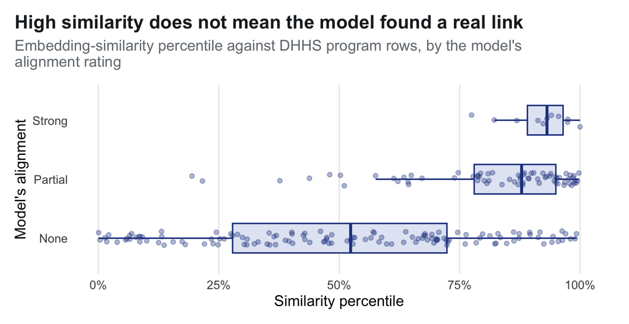

```r
if (labels_ok) {
  prog |> inner_join(filter(labels, labeled) |> select(opportunity_number, llm_align_dhhs), by = "opportunity_number") |>
    mutate(level = factor(str_to_sentence(llm_align_dhhs), levels = c("None", "Partial", "Strong"))) |>
    ggplot(aes(emb_pct, level)) +
    geom_boxplot(width = .5, outlier.shape = NA, fill = pal$blue_light, color = pal$blue) +
    geom_point(position = position_jitter(height = .12, width = 0, seed = SEED), alpha = .35, size = 1.4, color = pal$blue) +
    scale_x_continuous(labels = percent) +
    labs(title = "High similarity does not mean the model found a real link",
         subtitle = str_wrap("Embedding-similarity percentile against DHHS program rows, by the model's alignment rating", 80),
         x = "Similarity percentile", y = "Model's alignment") +
    theme(panel.grid.major.y = element_blank())
}
```

Opportunities the model rated *none* reach the top similarity percentiles too. Similarity is a hint, never the decision.

The table lists the opportunities whose ranking changed most when those rows were removed, with the plan row each one matched. Rows marked internal operations describe how the department runs itself (staffing, pay, contracting, buildings); grant boilerplate about staff, budgets and partners resembles them closely, so opportunities with no health or human services content rose toward the top. We removed those rows from alignment scoring (`alignable = FALSE` in the plan tables) and made the model’s judgment, which must cite a plan row and explain the link, the deciding signal for which agency sees an opportunity. Similarity scores remain only as a secondary hint.

# 16. Limitations

- **Match percentages are almost never published in structured form.** Only 6 of 1,662 rows state one anywhere in the export, against 117 flagged as requiring cost share. The labeler reads full announcements where they exist (116 of 278 candidates); forecasts usually have none.
- **The capability profiles describe real agencies from public sources**, not interviews with agency staff. Every row is sourced and editable, but a division head would know better.
- **The appropriation line ($1M) is an assumption.** No published NC rule sets it; the tool lets the user change it.
- **The local model is reliable on stated facts and weaker on judgment.** Against 60 blind hand labels it agrees on whether match is required 93% of the time, but on whether a state agency could lead the program only 67%, on DHHS alignment 59%, and it finds only 27% of the capabilities the team listed. Missed capabilities mean missed partner needs, so some Tier 1 results probably belong in Tier 2. It also once wrote its own rule (“work happens outside the United States”) into a field meant for a quote. It never assigns a tier, and every label it contributes is shown with its evidence (section 12).
- **Tiers 1-3 were not hand spot-checked.** The team reviewed the research awards but ran out of time to read each Tier 1-3 announcement; the blind hand-label comparison is the evidence for those tiers.
- **The eight domains have no veterans category.** Three hand labels used one; the model cannot choose it, and they count as disagreements.
- **Geography is domain-level.** County need describes where a program domain’s need concentrates, not where a statewide grant would be spent. County overdose data are NCHS model-based estimates for 2019-2021, the most recent years published; CDC WONDER’s county-level counts need its web form and data-use agreement.
- **The snapshot ages.** 355 posted opportunities had closed or been archived six weeks after the pull.
- **The DHHS plan is the one the competition provided (2023-2025, hosted by OSBM).** DHHS has since published 2024-2026 and 2026-2030 plans on its own site. The plan is an input table (`data/manual/dhhs_priorities.csv`), so updating it is a file swap followed by one re-labeling pass.
- **Community reach depends on the labeler’s population choice.** The tool can show where the people an opportunity serves live, but 170 of the 210 labeled opportunities were marked “all residents” or “system-level”, and some of those choices are too broad (the Preschool Development Grant is marked “all residents” rather than young children). District counts use the districts drawn for the 118th Congress; North Carolina redrew them for the 2024 election.
- **Awards are ceilings or estimates.** Where Grants.gov states a ceiling, the award shown is the most one award can be; actual awards are often smaller. Where it states none, the award is total funding ÷ expected awards, which the chart above shows can be far off, and is marked “est.”. A few opportunities have neither; they show no award and are never filtered out by the minimum-award setting.
- **People-served estimates are upper bounds.** They count the population an opportunity serves in NC, not people an award would reach.

# 17. What we would build with more time

- Pull full announcements for every opportunity weekly and diff them, so match percentages and deadlines update themselves.
- Replace keyword and similarity alignment with the DMVA plan’s own **Priority Questions**: an opportunity that helps answer a question the agency itself posed is a stronger match than one that shares vocabulary.
- Interview division staff to verify each capability’s control level.
- Add past award history (USAspending) by assistance listing to estimate competitiveness.
- Record standing partner agreements in the capability profile. Most Tier 2 opportunities (17 of 24 in the opening scenario) wait on a partner, mainly for research and evaluation or workforce training. Match authority matters less than we expected: full match authority moves only one opportunity from Tier 2 to Tier 1.
- Add veterans as a cross-cutting flag rather than a ninth domain, so DMVA-relevant programs in any domain surface together.
- Improve capability extraction, the model’s weakest measured field, by reading the full announcement’s program requirements section rather than an excerpt.

# 18. AI usage disclosure

This project used AI in two different roles. They are disclosed separately because they carry different risks.

## 1. AI inside the analysis: a local model that labels opportunities

**What it does.** A language model reads each candidate opportunity’s abstract and, where one exists, an excerpt of its full announcement (NOFO). It returns a fixed set of fields: whether a state agency could lead it, program domain, owning division, required capabilities, whether it requires subrecipients, evaluation, construction, a formal designation, or matching funds (with a verbatim quote as evidence), the population it serves, and how strongly it aligns with each agency’s strategic plan (with the plan row cited and a one-sentence rationale).

**Which model.** `qwen2.5:14b` (Q4_K_M quantization) run locally through Ollama on a laptop. No opportunity text was sent to a paid or cloud service. Plan-alignment similarity scores use a second local model, `nomic-embed-text`.

**Scope.** Only the candidate set is labeled: state-eligible, not NIH, and either open at the pull date or forecasted (278 opportunities, plus the three VA-issued ones). The other 1,300+ opportunities are handled by deterministic rules only.

**Controls on the model.** - Output must match a JSON schema with closed vocabularies (8 domains, 14 capabilities, 14 populations, the plan’s own row IDs). The model cannot invent a category. - Temperature 0 and a fixed seed. - Evidence fields must quote the source text verbatim, so a human can check them. - Every response is cached on disk under a hash of the model version, prompt version, and exact prompt. Re-rendering the notebook never calls the model and cannot change a label. The cache is committed so a teammate can reproduce every number without the model. - The model never decides a tier. Tiers come from written rules applied to the labels (`src/tool/tiering.js`), and every tier shows the rules that fired.

**How we checked it.** Sixty opportunities were drawn at random (stratified by status, issuing agency, and whether a full announcement exists) and labeled by team members who had not seen the model’s answers. The notebook reports accuracy, per-class precision and recall, and confusion matrices against those hand labels, and quotes real cases where the model was wrong.

**Known weaknesses.** The model can over-read alignment (in testing it once linked an economic development grant to health equity). That is why an opportunity only enters an agency’s view if the model also places it in one of the eight program domains, and why the alignment rationale is shown to the user rather than hidden inside a score.

## 2. AI as a development assistant

The team used Claude (Anthropic) through Claude Code as a coding and research assistant.

**What Claude did:** wrote most of the R pipeline, the JavaScript tier engine and interface, and the build and test scripts; checked the verified facts against the data; drafted the strategic-plan tables and the agency capability profile from the source documents and public web pages; found sources; and drafted parts of this notebook’s prose.

**What the team decided:** the user and the three-pile framing (from our interview), the five success criteria, the eight program domains, each capability’s control level, every threshold and default in `src/R/00_config.R`, and what to cut. Claude was instructed to ask rather than choose on these, and did.

**What humans verified:** - The 24 verified facts were computed independently before the build. The code must reproduce them, and one discrepancy (match-percentage mentions: 6, not 1) was checked by hand before the table was corrected. - The strategic-plan tables and capability profile carry a `human_verified` flag and source links for review. - The 60 hand labels are human work, done blind.

**Where AI-drafted material could still be wrong:** the capability control levels characterize real agencies from public sources, not from interviews with agency staff. The $1M appropriation line is a stated assumption, not a published rule. Both are editable in the tool’s Assumptions panel.

**Top-results rationales.** The one-sentence rationales in `outs/top_results_with_rationale.xlsx` were drafted by Claude from each opportunity’s Grants.gov description and the tool’s impact scores (`data/manual/top_results_rationales.csv`). Every figure in them was taken from the same row of the sheet. The team should review and edit them before submitting. The blank version, `outs/top_results_team.xlsx`, is there for the team to write their own.

# 19. Appendix: DMVA supplement

DMVA is a contrast case, not a parallel analysis. Its entire universe in this file is 3 VA-issued opportunities, 2 of them forecasts.

**DMVA’s opportunities, tiered as DMVA**

```r
dmva_settings <- modifyList(payload$config$opening, list(agency = "DMVA", include_forecasts = TRUE))
run_tiering_js(opps, payload$capabilities$profiles, dmva_settings) |>
  inner_join(filter(grants, is_va) |> select(opportunity_number, opportunity_title, status_group,
                                             award_ceiling_clean, is_cost_sharing, applicant_types), by = "opportunity_number") |>
  transmute(opportunity = opportunity_title, status = status_group, ceiling = usd_fmt(award_ceiling_clean),
            `cost share` = is_cost_sharing, eligible = applicant_types, placement, tier, reason = coalesce(tier_reason, placement_why)) |>
  dt(dom = "t")
```

| opportunity | status | ceiling | cost share | eligible | placement | tier | reason |
| --- | --- | --- | --- | --- | --- | --- | --- |
| GPD Grant Forecast | Forecasted |  | False | city_or_township_governments;special_district_governments;county_governments;state_governments;federally_recognized_native_american_tribal_governments;public_and_indian_housing_authorities;nonprofits_… | pile | 3 | Needs behavioral health service delivery, which DMVA has no route to; Needs housing stock or assistance, which DMVA reaches only through a partner |
| State Veterans Home Construction Grant Program | Posted | $275M | True | state_governments;federally_recognized_native_american_tribal_governments | pile | 3 | Cost share on a ~$275M award likely needs a state appropriation (line set at $1.0M); Capital construction project; Requires a formal state designation (e.g. by the Governor); Needs capital constructio… |
| Veterans Legacy Grants Program | Forecasted | $400K | False | public_and_state_institutions_of_higher_education;independent_school_districts;state_governments;private_institutions_of_higher_education;nonprofits_non_higher_education_with_501c3 | pile | 3 | Needs public health surveillance, which DMVA has no route to |

**The DMVA plan objective it maps to**

```r
g <- load_priorities() |> filter(priority_id == "G2.O1", agency == "DMVA")
cat("> **DMVA Goal 2, Objective 1 (p. ", g$page, "):** ", g$text, "\n", sep = "")
```

> **DMVA Goal 2, Objective 1 (p. 7):** Modernize the State Veterans Homes infrastructure and proactively identify and improve preventative maintenance by partnering with the State Construction Office’s Facilities Condition Assessment Program (FCAP) to conduct facility assessments of the homes to determine priority repairs and deferred maintenance.

The one posted DMVA opportunity, the State Veterans Home Construction Grant Program, matches DMVA’s own current goal of modernizing the veterans homes, and lands in Tier 3 because a capital construction project with cost share needs an appropriation. The agency’s best match is the thing it cannot act on alone. The DMVA plan also lists explicit *Priority Questions*; aligning opportunities to those questions is the natural next feature (section 17).